# Final Project - EDA

Huy Le

March 21, 2019

# 1 Commented header

```r
# Course: BUAN 5210
# Title: Final Project
# Purpose: Technical Appendix
# Date: 2019-03-14
# Author: Huy LE
```

# 2 Clear environment

```r
# Clear environment of variables and functions
rm(list = ls(all = TRUE))

# Clear environmet of packages
if(is.null(sessionInfo()$otherPkgs) == FALSE)lapply(paste("package:", names(sessionInfo()$otherPkgs), sep=""), detach, character.only = TRUE, unload = TRUE)
```

# 3 Load packages

```r
# Load libraries
library(tidyverse)
library(GGally)
library(gridExtra)
library(kableExtra)
library(janitor)
library(stringr)
library(knitr)
library(htmlTable)
library(lubridate)
library(aod)
library(sjPlot)
library(MultinomialCI)
library(Hmisc)
library(ggrepel)
library(rworldmap)
```

# 4. Load data

```r
# Load data
kick <- read.csv("./ks-projects-201801.csv")

# Examine data structure
str(kick)
```

```
## 'data.frame':    378661 obs. of  15 variables:
##  $ ID              : int  1000002330 1000003930 1000004038 1000007540 1000011046 1000014025 1000023410 1000030581 1000034518 100004195 ...
##  $ name            : Factor w/ 375765 levels "","\177Not Twins - New EP! \"The View from Down Here\"",..: 332541 135689 365010 344805 77349 206130 293462 69360 284139 290718 ...
##  $ category        : Factor w/ 159 levels "3D Printing",..: 109 94 94 91 56 124 59 42 114 40 ...
##  $ main_category   : Factor w/ 15 levels "Art","Comics",..: 13 7 7 11 7 8 8 8 5 7 ...
##  $ currency        : Factor w/ 14 levels "AUD","CAD","CHF",..: 6 14 14 14 14 14 14 14 14 14 ...
##  $ deadline        : Factor w/ 3164 levels "2009-05-03","2009-05-16",..: 2288 3042 1333 1017 2247 2463 1996 2448 1790 1863 ...
##  $ goal            : num  1000 30000 45000 5000 19500 50000 1000 25000 125000 65000 ...
##  $ launched        : Factor w/ 378089 levels "1970-01-01 01:00:00",..: 243292 361975 80409 46557 235943 278600 187500 274014 139367 153766 ...
##  $ pledged         : num  0 2421 220 1 1283 ...
##  $ state           : Factor w/ 6 levels "canceled","failed",..: 2 2 2 2 1 4 4 2 1 1 ...
##  $ backers         : int  0 15 3 1 14 224 16 40 58 43 ...
##  $ country         : Factor w/ 23 levels "AT","AU","BE",..: 10 23 23 23 23 23 23 23 23 23 ...
##  $ usd.pledged     : num  0 100 220 1 1283 ...
##  $ usd_pledged_real: num  0 2421 220 1 1283 ...
##  $ usd_goal_real   : num  1534 30000 45000 5000 19500 ...
```

- 378661 Obs, 15 variables
- 23 countries, 14 currencies, 159 category, 15 main categories, 6 state.

## 4.1 Tidying data

```r
#check na value
sapply(kick, function(x) sum(is.na(x)))
```

```
##               ID             name         category    main_category
##                0                0                0                0
##         currency         deadline             goal         launched
##                0                0                0                0
##          pledged            state          backers          country
##                0                0                0                0
##      usd.pledged usd_pledged_real    usd_goal_real
##             3797                0                0
```

```r
sapply(kick, function(x) sum(is.infinite(x)))
```

```
##               ID             name         category    main_category
##                0                0                0                0
##         currency         deadline             goal         launched
##                0                0                0                0
##          pledged            state          backers          country
##                0                0                0                0
##      usd.pledged usd_pledged_real    usd_goal_real
##                0                0                0
```

- There appears to only be N/A values for usd.pledged. We actually don’t need that column since we’ll be using usd_pledged_real instead, so let’s get rid of it and rename usd_pledged_real to usd.pledged. Likewise, we’ll do the same with usd_goal_real and simply name it usd.goal.

```r
#check odds value
summary(kick)
```

```
##        ID                                  name
##  Min.   :5.971e+03   New EP/Music Development:    41
##  1st Qu.:5.383e+08   Canceled (Canceled)     :    13
##  Median :1.075e+09   Music Video             :    11
##  Mean   :1.075e+09   N/A (Canceled)          :    11
##  3rd Qu.:1.610e+09   Cancelled (Canceled)    :    10
##  Max.   :2.147e+09   Debut Album             :    10
##                      (Other)                 :378565
##            category           main_category       currency
##  Product Design: 22314   Film & Video: 63585   USD    :295365
##  Documentary   : 16139   Music       : 51918   GBP    : 34132
##  Music         : 15727   Publishing  : 39874   EUR    : 17405
##  Tabletop Games: 14180   Games       : 35231   CAD    : 14962
##  Shorts        : 12357   Technology  : 32569   AUD    :  7950
##  Video Games   : 11830   Design      : 30070   SEK    :  1788
##  (Other)       :286114   (Other)     :125414   (Other):  7059
##        deadline           goal                          launched
##  2014-08-08:   705   Min.   :        0   1970-01-01 01:00:00:     7
##  2014-08-10:   558   1st Qu.:     2000   2009-09-15 05:56:28:     2
##  2014-08-07:   541   Median :     5200   2010-06-30 17:29:43:     2
##  2015-05-01:   489   Mean   :    49081   2011-02-08 04:29:48:     2
##  2014-08-09:   477   3rd Qu.:    16000   2011-02-25 09:58:36:     2
##  2015-07-01:   449   Max.   :100000000   2011-03-03 17:55:38:     2
##  (Other)   :375442                       (Other)            :378644
##     pledged                state           backers
##  Min.   :       0   canceled  : 38779   Min.   :     0.0
##  1st Qu.:      30   failed    :197719   1st Qu.:     2.0
##  Median :     620   live      :  2799   Median :    12.0
##  Mean   :    9683   successful:133956   Mean   :   105.6
##  3rd Qu.:    4076   suspended :  1846   3rd Qu.:    56.0
##  Max.   :20338986   undefined :  3562   Max.   :219382.0
##
##     country        usd.pledged       usd_pledged_real
##  US     :292627   Min.   :       0   Min.   :       0
##  GB     : 33672   1st Qu.:      17   1st Qu.:      31
##  CA     : 14756   Median :     395   Median :     624
##  AU     :  7839   Mean   :    7037   Mean   :    9059
##  DE     :  4171   3rd Qu.:    3034   3rd Qu.:    4050
##  N,0"   :  3797   Max.   :20338986   Max.   :20338986
##  (Other): 21799   NA's   :3797
##  usd_goal_real
##  Min.   :        0
##  1st Qu.:     2000
##  Median :     5500
##  Mean   :    45454
##  3rd Qu.:    15500
##  Max.   :166361391
##
```

- Dataset from 2009 to 2018. But I only analyse data in 2017
- convert launched, deadline to date type.
- uds_plefged_real, and usd_goal_real are the real converstion of pledged and goal to usd. we will use these instead pledged and goal.
- Some project set up the goal too low (0.01 usd or 10 usd), it more likely to success than other. I will limit projects with usd.goal > 1000 usd.
- Variable “State” indicate the status of a project Failed, Sccessful, suspended, undefined.
  - To conduct regression model, I will restrict those projects were canceled or suspended.
- I want to know duration of a project and how much a project succesful over expectation.
  - I will create new fields. Duration = Deadline - launch date (days), ratio = usd.pledged / usd.goal.
  - The maximum for project length on Kickstater is 60 days but there might be some more.

```r
#format date as yyyy-mm-dd
#filter data
dat <- kick %>%
        select(-usd.pledged, - name,goal, - pledged) %>%
        rename(usd.pledged = usd_pledged_real,
               usd.goal = usd_goal_real,
               #change the name of category and main_category for easy coding
               category = main_category ,
               subcategory = category) %>%
# convert character into factor, data
        mutate(ID = as.factor(ID),
               deadline = as.Date(deadline),
               launched = as.Date(launched)) %>%
        mutate(duration = as.numeric(deadline -launched),
               ratio = round(usd.pledged/usd.goal,2),
               year = format(launched, "%Y"),
               month =  format(launched, "%m")) %>%
#filter data follow selection criteria
        filter( launched >= as.Date("2017-01-01") & launched <= as.Date("2017-12-31") &
                usd.goal >= 1000 &
                country !='N,0"' &
                duration <= 60 &
                (state == "successful" | state == "failed"))%>%
        mutate(state =  factor(state, levels = c("failed", "successful")))


#Check duplicate data
sum(duplicated(dat$ID))
```

```
## [1] 0
```

- Now, the data is look better

# 5. Basic EDA

## 5.1 Univariate Analysis

### 5.1.1 Non-graphical Analysis

```r
# descriptive statistics
summary(dat)
```

```
##        ID                subcategory            category
##  48139  :    1   Product Design: 3288   Games       : 4604
##  76298  :    1   Tabletop Games: 2216   Technology  : 4455
##  151549 :    1   Music         : 1306   Design      : 4106
##  189772 :    1   Apparel       : 1130   Film & Video: 4005
##  285583 :    1   Video Games   : 1087   Publishing  : 3822
##  329144 :    1   Apps          : 1069   Music       : 3667
##  (Other):36536   (Other)       :26446   (Other)     :11883
##     currency        deadline               goal
##  USD    :23642   Min.   :2017-01-06   Min.   :      750
##  EUR    : 3844   1st Qu.:2017-04-27   1st Qu.:     3487
##  GBP    : 3776   Median :2017-07-15   Median :     9000
##  CAD    : 1677   Mean   :2017-07-18   Mean   :    64166
##  AUD    : 1012   3rd Qu.:2017-10-11   3rd Qu.:    22000
##  MXN    :  939   Max.   :2018-01-02   Max.   :100000000
##  (Other): 1652
##     launched                 state          backers           country
##  Min.   :2017-01-01   failed    :22189   Min.   :    0.0   US     :23642
##  1st Qu.:2017-03-24   successful:14353   1st Qu.:    2.0   GB     : 3776
##  Median :2017-06-12                      Median :   18.0   CA     : 1677
##  Mean   :2017-06-15                      Mean   :  165.6   AU     : 1012
##  3rd Qu.:2017-09-07                      3rd Qu.:   90.0   DE     :  980
##  Max.   :2017-12-22                      Max.   :43733.0   MX     :  939
##                                                            (Other): 4516
##   usd.pledged         usd.goal            duration         ratio
##  Min.   :      0   Min.   :     1000   Min.   : 1.00   Min.   :  0.000
##  1st Qu.:     55   1st Qu.:     3114   1st Qu.:30.00   1st Qu.:  0.010
##  Median :   1254   Median :     7500   Median :30.00   Median :  0.170
##  Mean   :  15915   Mean   :    46335   Mean   :32.95   Mean   :  1.144
##  3rd Qu.:   7022   3rd Qu.:    20000   3rd Qu.:35.00   3rd Qu.:  1.110
##  Max.   :7072757   Max.   :107369868   Max.   :60.00   Max.   :327.810
##
##      year              month
##  Length:36542       Length:36542
##  Class :character   Class :character
##  Mode  :character   Mode  :character
##
##
##
##
```

#### Frequency table

```r
#Create function for frequency tables
count_table <- function(x,colname){
   x = enquo(x)
   dat %>%
      tabyl(!!x) %>%
      adorn_totals()%>%
      adorn_pct_formatting(digits = 0 ) %>%
   kable(
      digits = 2,
      align = c("l","c","c"),
      col.names = c(colname,"Count","Percent")) %>%
  kable_styling(c("bordered"), position = "center", full_width = F)
   }

#Make count tables for univariate variables
count_table(category,"Category")
```

| Category | Count | Percent |
| --- | --- | --- |
| Art | 2173 | 6% |
| Comics | 1344 | 4% |
| Crafts | 915 | 3% |
| Dance | 291 | 1% |
| Design | 4106 | 11% |
| Fashion | 2747 | 8% |
| Film & Video | 4005 | 11% |
| Food | 2573 | 7% |
| Games | 4604 | 13% |
| Journalism | 419 | 1% |
| Music | 3667 | 10% |
| Photography | 745 | 2% |
| Publishing | 3822 | 10% |
| Technology | 4455 | 12% |
| Theater | 676 | 2% |
| Total | 36542 | 100% |

- Game has most project, account for 13%, follow by Technology 12%, Desgin 11%, Film & Video 11%.
- The leasts are Dance, Journalism with 1%

#### Now I’ll do the same thing for subcategory. There are 159 subcategory, I will do with just top 10 subcategories

```r
dat %>%
    group_by(subcategory) %>%
    summarise(count = n()) %>%
    mutate(percent = round(count /sum(count)*100,2))%>%
    arrange(desc(count)) %>%
    head(10) %>%
    kable() %>%
    kable_styling(c("bordered"), position = "center", full_width = F)
```

| subcategory | count | percent |
| --- | --- | --- |
| Product Design | 3288 | 9.00 |
| Tabletop Games | 2216 | 6.06 |
| Music | 1306 | 3.57 |
| Apparel | 1130 | 3.09 |
| Video Games | 1087 | 2.97 |
| Apps | 1069 | 2.93 |
| Documentary | 937 | 2.56 |
| Children’s Books | 847 | 2.32 |
| Technology | 761 | 2.08 |
| Art | 712 | 1.95 |

- Product Design (Design main category) hase most project 3288.

#### Currency

```r
count_table(currency,"Currency")
```

| Currency | Count | Percent |
| --- | --- | --- |
| AUD | 1012 | 3% |
| CAD | 1677 | 5% |
| CHF | 215 | 1% |
| DKK | 157 | 0% |
| EUR | 3844 | 11% |
| GBP | 3776 | 10% |
| HKD | 333 | 1% |
| JPY | 20 | 0% |
| MXN | 939 | 3% |
| NOK | 106 | 0% |
| NZD | 200 | 1% |
| SEK | 352 | 1% |
| SGD | 269 | 1% |
| USD | 23642 | 65% |
| Total | 36542 | 100% |

- Most projects were launched in USD 65% followed by EUR with 11%, GBP 10%, these orthers were not subtaintial

#### Country

```r
count_table(country,"Country")
```

| Country | Count | Percent |
| --- | --- | --- |
| AT | 157 | 0% |
| AU | 1012 | 3% |
| BE | 149 | 0% |
| CA | 1677 | 5% |
| CH | 215 | 1% |
| DE | 980 | 3% |
| DK | 157 | 0% |
| ES | 539 | 1% |
| FR | 720 | 2% |
| GB | 3776 | 10% |
| HK | 333 | 1% |
| IE | 153 | 0% |
| IT | 728 | 2% |
| JP | 20 | 0% |
| LU | 16 | 0% |
| MX | 939 | 3% |
| N,0" | 0 | 0% |
| NL | 402 | 1% |
| NO | 106 | 0% |
| NZ | 200 | 1% |
| SE | 352 | 1% |
| SG | 269 | 1% |
| US | 23642 | 65% |
| Total | 36542 | 100% |

- The proportion in country is similar with currency.

#### Project status

```r
count_table(state,"Status")
```

| Status | Count | Percent |
| --- | --- | --- |
| failed | 22189 | 61% |
| successful | 14353 | 39% |
| Total | 36542 | 100% |

- 61% projects was failed, 39% is successfull

### 5.1.2 Graphical Analysis

#### 5.1.2.1 Categorical variables

#### Create functions

```r
#Count bargraph
count_bargraph <- function(plot) {
 plot +
    geom_bar(position = "dodge") +
    theme_bw() +
    theme(panel.border = element_blank(),
                       panel.grid.major = element_blank(),
                       panel.grid.minor = element_blank()) +
    labs(y ="Count")
}

#Count histogram
count_hist<- function(plot){
  plot + geom_histogram(bins = 52)+
    theme_bw() +
    theme(panel.border = element_blank(),
                       panel.grid.major = element_blank(),
                       panel.grid.minor = element_blank()) +
    labs(y ="Count")
}

# nrow(dat[dat$usd.pledged < 2000,])
# dat %>%
#   mutate(year)
# ggplot(mapping =aes(x=format(launched,"%Y"))) +
#   geom_line(stat='count')
#
# hist(dat$usd.goal)
```

#### Summary graph

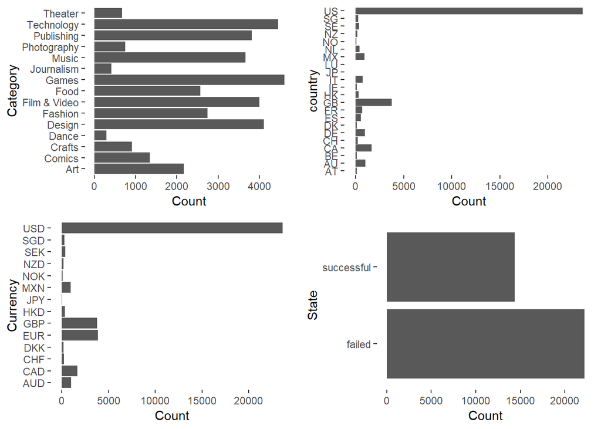

```r
grid.arrange(
  count_bargraph(ggplot(dat, aes(category))) +
                          xlab("Category") +
                          coord_flip(),
  count_bargraph(ggplot(dat, aes(country))) +
                          xlab("country")+
                            coord_flip(),
  count_bargraph(ggplot(dat, aes(currency))) +
                          xlab("Currency")+
                            coord_flip(),
  count_bargraph(ggplot(dat, aes(state))) +
                          xlab("State") + coord_flip(),
  nrow = 2)
```

#### 5.1.2.2 Quantitive variable

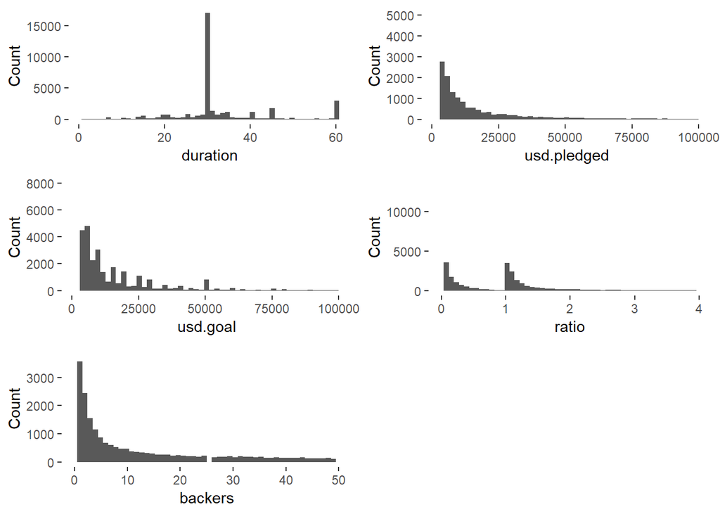

```r
#Project frequency in continuous variable

grid.arrange(
  count_hist(ggplot(dat, aes(duration))), #uration
  count_hist(ggplot(dat, aes(usd.pledged))+ xlim(1000, 100000)), #total usd amount pledge
  count_hist(ggplot(dat, aes(usd.goal))+ xlim(1000, 100000)), #Minimum goal
  count_hist(ggplot(dat, aes(ratio))+ xlim(0, 4)), #ratio = pledged/goal
  count_hist(ggplot(dat, aes(backers))+ xlim(0, 50)), #number of backer
nrow = 3
)
```

```r
# dat %>% ggplot(aes(x="", y = usd.pledged)) +
#         geom_boxplot() +
#         ylim(1000, 100000)
```

## 5.2 Multivariate Analysis

### 5.2.1 Non-graphical Analysis

#### 5.2.1.1 Categorical variables

```r
#Function for table
count_crosstable <- function(x, y, name, cols){
   x = enquo(x)
   y = enquo(y)
   dat %>%
      tabyl(!!x, !!y) %>%
      adorn_totals(where = c('row','col')) %>%
      #adorn_pct_formatting(digits = 0 ) %>%
   kable(
     digits = 2,
      format = "html",
      align = c("l","c","c","c","c"),
      caption = name,
      col.names = cols
    )%>%
  kable_styling(full_width = F, c("bordered"), position = "center")
}
prop_crosstable <- function(x, y, name, cols, denom = "all"){
   x = enquo(x)
   y = enquo(y)
   dat %>%
      tabyl(!!x, !!y) %>%
      adorn_totals(where = c('row','col')) %>%
      adorn_percentages(denominator = denom)%>%
      adorn_pct_formatting(digits = 0 ) %>%
   kable(
     digits = 2,
      format = "html",
      align = c("l","c","c","c","c"),
      caption = name,
      col.names = cols
    )%>%
  kable_styling(full_width = F, c("bordered"), position = "center")
}
```

##### Main category - Subcategory

```r
#Main Category - sub categoty
dat %>%
    select(subcategory, category) %>% distinct() %>%
    group_by(category) %>%
    summarise(Num_subcategory = n()) %>%
    kable(col.names = c("Category", "Subcategory")) %>%
    kable_styling(full_width = F,c("bordered"), position = "center")
```

| Category | Subcategory |
| --- | --- |
| Art | 13 |
| Comics | 6 |
| Crafts | 13 |
| Dance | 5 |
| Design | 7 |
| Fashion | 9 |
| Film & Video | 20 |
| Food | 13 |
| Games | 8 |
| Journalism | 6 |
| Music | 19 |
| Photography | 7 |
| Publishing | 18 |
| Technology | 16 |
| Theater | 8 |

- Film & video is the category has most subcategory, the least cateogry is Dance.

##### Successful and Unsuccessful

```r
#Successful vs failed by category
prop_crosstable(category, state,"Successfull vs Failed", c("Category", "Failed", "Successful", "Total"), "row")
```

Successfull vs Failed

| Category | Failed | Successful | Total |
| --- | --- | --- | --- |
| Art | 59% | 41% | 100% |
| Comics | 35% | 65% | 100% |
| Crafts | 78% | 22% | 100% |
| Dance | 38% | 62% | 100% |
| Design | 53% | 47% | 100% |
| Fashion | 72% | 28% | 100% |
| Film & Video | 61% | 39% | 100% |
| Food | 75% | 25% | 100% |
| Games | 50% | 50% | 100% |
| Journalism | 79% | 21% | 100% |
| Music | 51% | 49% | 100% |
| Photography | 63% | 37% | 100% |
| Publishing | 62% | 38% | 100% |
| Technology | 77% | 23% | 100% |
| Theater | 41% | 59% | 100% |
| Total | 61% | 39% | 100% |

#### 5.2.1.2 Quantitative variables

```r
#
average_summarise <- function(x, y, tablename) {
   x = enquo(x)
   y = enquo(y)
   dat %>%
      select(!!x, !!y) %>%
      group_by(!!x) %>%
      summarise(Mean = mean(!!y), Min = min(!!y), max = max(!!y), sd = sd(!!y) ) %>%
      #adorn_pct_formatting(digits = 0 ) %>%
   kable(
     digits = 2,
      format = "html",
      align = c("l","c","c","c","c"),
      caption = tablename
    )%>%
  kable_styling(full_width = F, c("bordered"), position = "center")

}

# Usd pledged in category
average_summarise(category, usd.pledged, "USD pledged in Category")
```

USD pledged in Category

| category | Mean | Min | max | sd |
| --- | --- | --- | --- | --- |
| Art | 6791.45 | 0 | 1364835.4 | 42860.24 |
| Comics | 8529.51 | 0 | 260942.1 | 20067.51 |
| Crafts | 2845.26 | 0 | 198737.5 | 11409.93 |
| Dance | 4203.35 | 0 | 34856.0 | 5498.72 |
| Design | 36580.38 | 0 | 4729263.1 | 166421.06 |
| Fashion | 8523.84 | 0 | 1265430.4 | 38665.04 |
| Film & Video | 7564.26 | 0 | 595676.1 | 23778.84 |
| Food | 6591.03 | 0 | 1927217.0 | 43842.15 |
| Games | 32453.36 | 0 | 7072757.0 | 198257.34 |
| Journalism | 3983.28 | 0 | 215487.8 | 15014.37 |
| Music | 5324.30 | 0 | 368841.0 | 13587.65 |
| Photography | 8670.26 | 0 | 702292.1 | 42110.22 |
| Publishing | 6088.94 | 0 | 866193.5 | 24618.89 |
| Technology | 28542.11 | 0 | 5333792.8 | 168705.89 |
| Theater | 4684.51 | 0 | 102997.8 | 8590.01 |

##### Usd goal in category

```r
#Usd.goal by category
average_summarise(category, usd.goal, "USD goal in Category")
```

USD goal in Category

| category | Mean | Min | max | sd |
| --- | --- | --- | --- | --- |
| Art | 72534.95 | 1000 | 100000000.0 | 2230474.78 |
| Comics | 8355.00 | 1000 | 800000.0 | 26142.40 |
| Crafts | 11002.74 | 1000 | 668869.5 | 31954.89 |
| Dance | 10265.10 | 1000 | 275000.0 | 24752.29 |
| Design | 25640.89 | 1000 | 8000000.0 | 134105.65 |
| Fashion | 23768.25 | 1000 | 17708935.9 | 342465.31 |
| Film & Video | 174515.92 | 1000 | 107369867.7 | 3138868.87 |
| Food | 29966.53 | 1000 | 1750000.0 | 75068.96 |
| Games | 22699.16 | 1000 | 5000000.0 | 106946.18 |
| Journalism | 49499.44 | 1000 | 10000000.0 | 498155.46 |
| Music | 17604.29 | 1000 | 5000000.0 | 123685.73 |
| Photography | 12464.16 | 1000 | 480000.0 | 25205.60 |
| Publishing | 17683.49 | 1000 | 9000000.0 | 206427.95 |
| Technology | 62669.65 | 1000 | 11795930.4 | 321838.73 |
| Theater | 27822.17 | 1000 | 5500000.0 | 258527.30 |

##### Average Number of backers, USD pledged, USD goal and ratio in category

```r
dat %>% select(category, backers, usd.pledged, usd.goal) %>%
        group_by(category) %>%
        summarise(Avg_backers = round(mean(backers),0),
                  Avg_pledged =  round(mean(usd.pledged),0),
                  Avg_goal =  round(mean(usd.goal),0),
                  Avg_ratio =  round(Avg_pledged/Avg_goal,2)) %>%
        arrange(desc(Avg_ratio)) %>%
        kable(
           digits = 2,
            format = "html",
            align = c("l","c","c","c","c"),
            caption = "Averages by Categories",
            col.names = c("Category", "Average Backers", "Average Pledged", "Average goal", "Average Ratio")
          )%>%
        kable_styling(full_width = F, c("bordered"), position = "center")
```

Averages by Categories

| Category | Average Backers | Average Pledged | Average goal | Average Ratio |
| --- | --- | --- | --- | --- |
| Design | 314 | 36580 | 25641 | 1.43 |
| Games | 438 | 32453 | 22699 | 1.43 |
| Comics | 180 | 8530 | 8355 | 1.02 |
| Photography | 77 | 8670 | 12464 | 0.70 |
| Technology | 187 | 28542 | 62670 | 0.46 |
| Dance | 44 | 4203 | 10265 | 0.41 |
| Fashion | 75 | 8524 | 23768 | 0.36 |
| Publishing | 99 | 6089 | 17683 | 0.34 |
| Music | 72 | 5324 | 17604 | 0.30 |
| Crafts | 38 | 2845 | 11003 | 0.26 |
| Food | 60 | 6591 | 29967 | 0.22 |
| Theater | 52 | 4685 | 27822 | 0.17 |
| Art | 89 | 6791 | 72535 | 0.09 |
| Journalism | 54 | 3983 | 49499 | 0.08 |
| Film & Video | 77 | 7564 | 174516 | 0.04 |

- Games and Design have most backers , also highest ratio (Pledged amount/Goal)

##### Correltaion between continuous variables

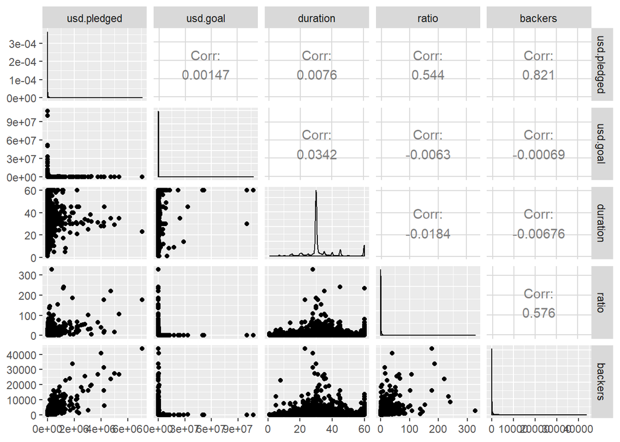

```r
ggpairs(dat, columns =  c("usd.pledged", "usd.goal", "duration", "ratio", "backers"))
```

### 5.2.2 Graphical Analysis

#### 5.2.2.1 What are popular project categories?

##### Numer of Project by category

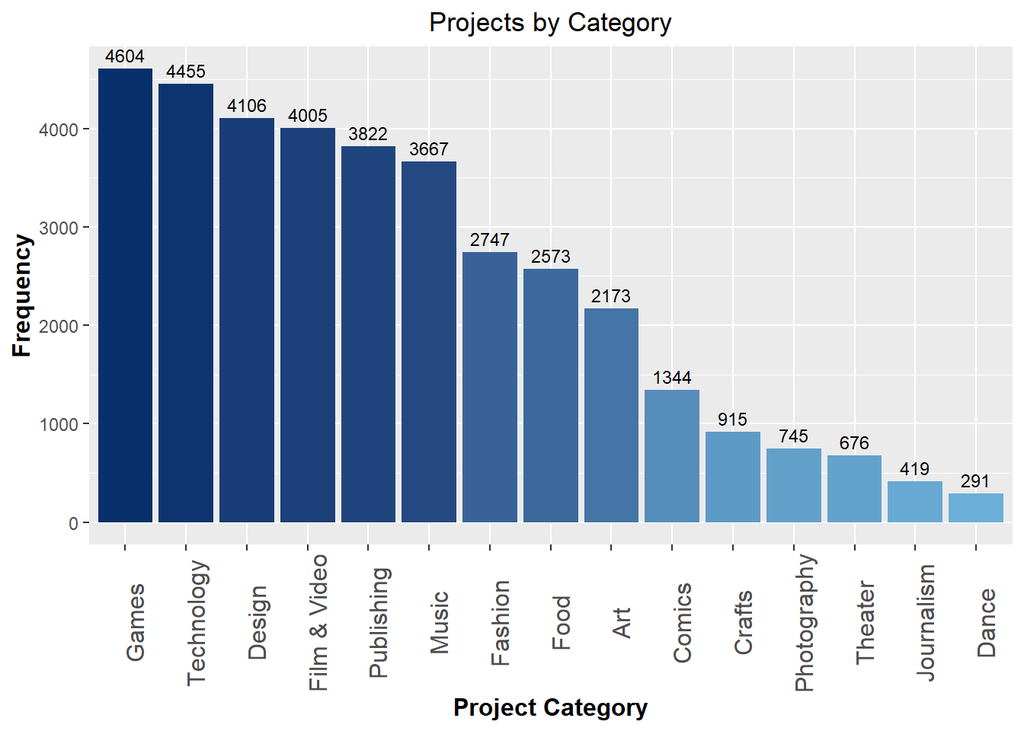

```r
dat %>%
  group_by(category) %>%
  summarise(count=n()) %>%
  arrange(desc(count)) %>%
  mutate(category = factor(category, levels=category)) %>%
  ggplot( aes(category, count, fill = count)) + geom_bar(stat="identity") +
  ggtitle("Projects by Category") + xlab("Project Category") + ylab("Frequency") +
  geom_text(aes(label=count), vjust=-0.5, size = 3) +
  theme(plot.title=element_text(hjust=0.5), axis.title=element_text(size=12, face="bold"),
        axis.text.x=element_text(size=12, angle=90), legend.position="null") +
  scale_fill_gradient(low="#6baed6", high="#08306b")
```

- Game and Technology have more projects than other categories

##### Success vs Failure

[output not shown]

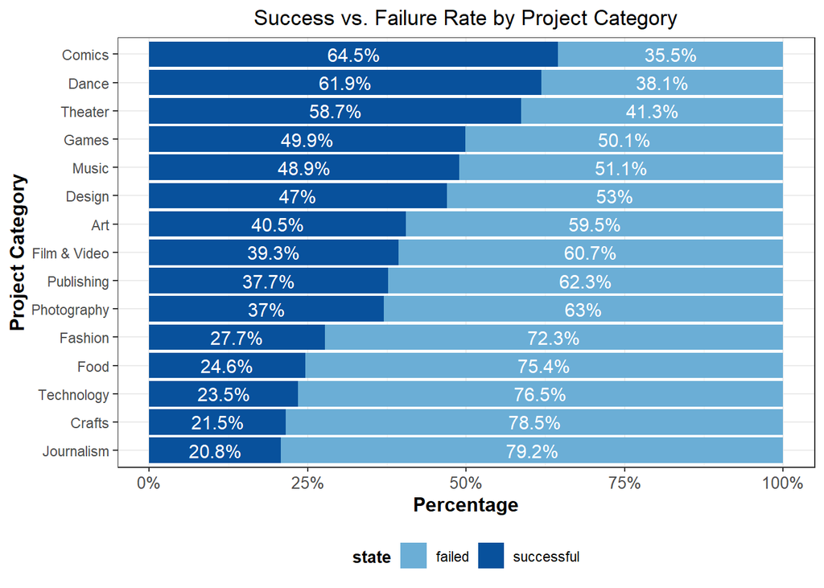

```r
# Successfull vs Failure by category
 state.pct <-dat %>%
  group_by(category, state) %>%
  summarise(count=n()) %>%
  mutate(pct=count/sum(count)) %>%
  arrange(desc(state), pct)
  state.pct$category <-factor(state.pct$category,
                                  levels=state.pct$category[1:(nrow(state.pct)/2)])
  state.pct %>% ggplot(aes(x=category, y= pct, fill = state)) + geom_bar(stat = "identity") +
  ggtitle("Success vs. Failure Rate by Project Category") +
  xlab("Project Category") + ylab("Percentage") + scale_y_continuous(labels = scales::percent) +
  scale_fill_discrete(name="Project Status", breaks=c("successful", "failed"),
                      labels=c("Success", "Failure")) +
  geom_text(aes(label=paste0(round(pct*100,1),"%")), position=position_stack(vjust=0.5),
            colour="white", size=4) +
  theme_bw() +
  theme(plot.title=element_text(hjust=0.5), axis.title=element_text(size=12, face="bold"),
        axis.text.x=element_text(size=10), legend.position="bottom",
        legend.title=element_text(size=10, face="bold")) +
  coord_flip() +
  scale_fill_manual(values = c("#6baed6","#08519c"))
```

##### Vaerage backers per project by category

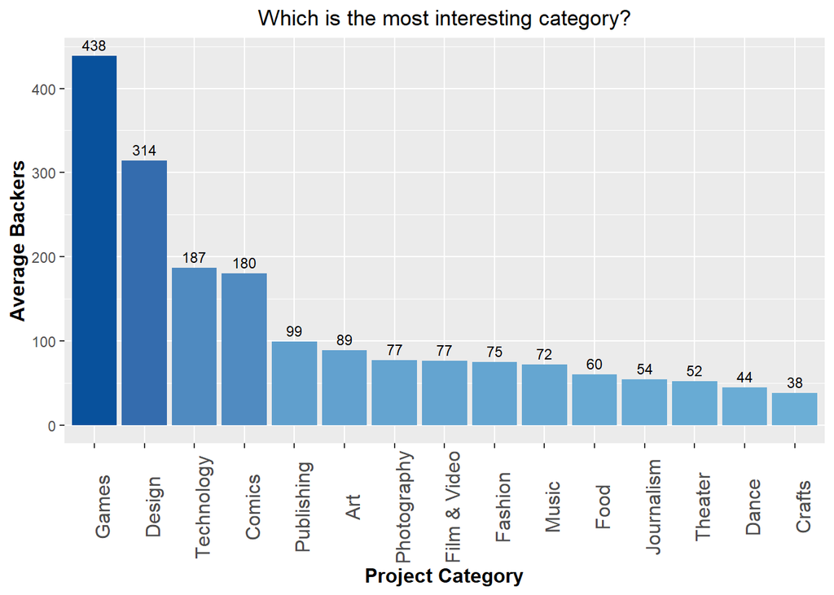

```r
dat %>%
  group_by(category) %>%
  summarise(sumbackers = mean(backers)) %>%
  arrange(desc(sumbackers)) %>%
  mutate(category = factor(category, levels=category)) %>%
  ggplot( aes(category, sumbackers, fill=sumbackers)) + geom_bar(stat="identity") +
  ggtitle("Which is the most interesting category?") + xlab("Project Category") + ylab("Average Backers") +
  geom_text(aes(label= round(sumbackers,0)), vjust=-0.5, size = 3) +
  theme(plot.title=element_text(hjust=0.5), axis.title=element_text(size=12, face="bold"),
        axis.text.x=element_text(size=12, angle=90), legend.position="null") +
  scale_fill_gradient(low="#6baed6", high= "#08519c")
```

- Game projects revceive many support from backers, incredibly higher than these others.
- Number of backers of Game project is double to Technology as success rate. May it is the reason of success?

#### 5.2.2.2 Minimum goal and funding amount

##### Correlation Goal and Funding result

Whether setup project goal affect to success?

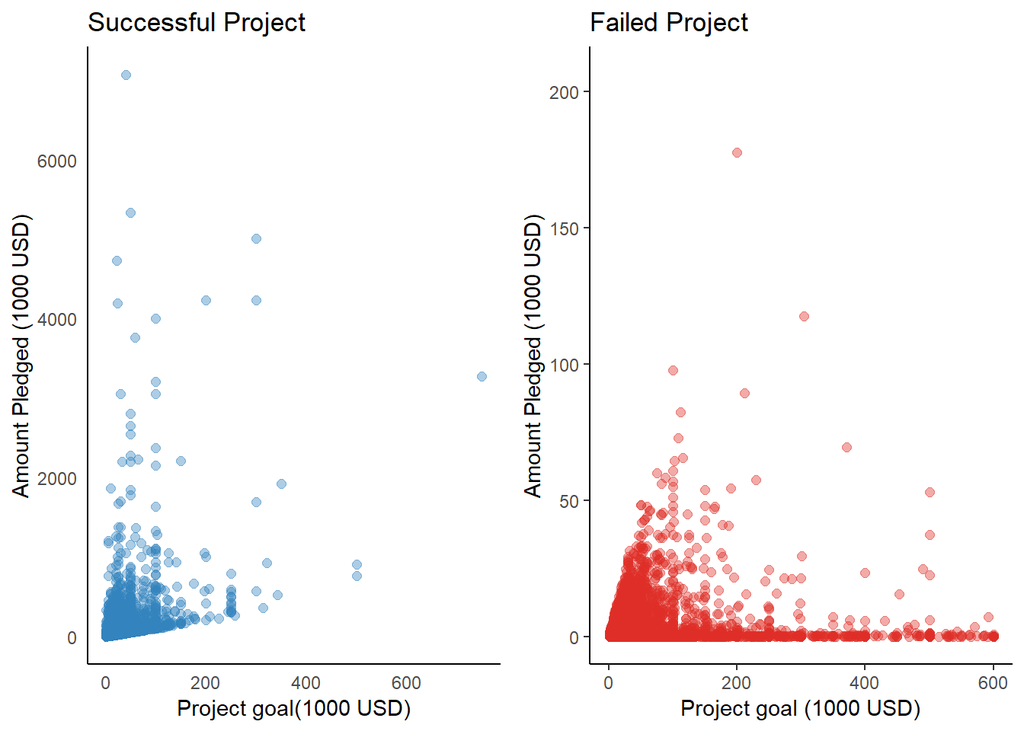

```r
grid.arrange(
  dat %>% filter(state =="successful") %>%
  ggplot(aes(x= usd.goal/1000, y = usd.pledged/1000)) +
  geom_point(alpha =0.4, size = 2, colour = "#3182bd") +
  ggtitle("Successful Project") +
  xlab("Project goal(1000 USD)") + ylab("Amount Pledged (1000 USD)") +
  theme_bw() +
  theme(panel.grid =element_blank()) +
  theme(axis.ticks = element_blank()) +
  theme(axis.line = element_line(colour = "black")) +
  theme(panel.border = element_blank()),
  dat %>% filter(state =="failed") %>%
  ggplot(aes(x= usd.goal/1000, y = usd.pledged/1000)) +
  geom_point(alpha =0.4, size = 2, colour = "#de2d26") +
  ggtitle("Failed Project") +
  xlab("Project goal (1000 USD)") + ylab("Amount Pledged (1000 USD)") +
  theme_bw() +
  theme(panel.grid =element_blank()) +
  theme(axis.line = element_line(colour = "black")) +
  theme(panel.border = element_blank()) +
  xlim(0, 600),
  nrow =1)
```

- Most projects set the goal too high are failed. While smaller goal project fund raise more
  - Higher goal face more risk than lower goal

##### Pledged amount vs number of backers

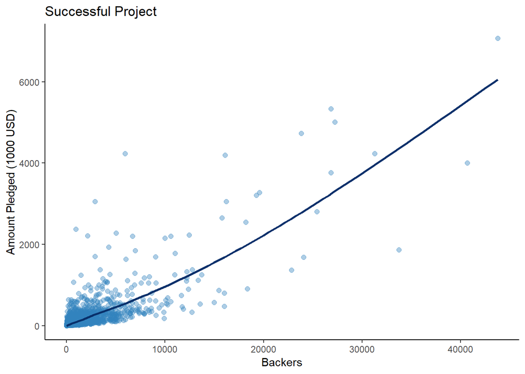

```r
dat %>%
  #filter(state =="successful") %>%
  ggplot(aes(x=backers, y = usd.pledged/1000)) +
  geom_point(alpha =0.4, size = 2, colour = "#3182bd") +
  geom_smooth( se =FALSE, colour = "#08306b")+
  ggtitle("Successful Project") +
  xlab("Backers") + ylab("Amount Pledged (1000 USD)") +
  theme_bw() +
  theme(panel.grid =element_blank()) +
  theme(axis.line = element_line(colour = "black")) +
  theme(panel.border = element_blank())
```

##### Average project goal

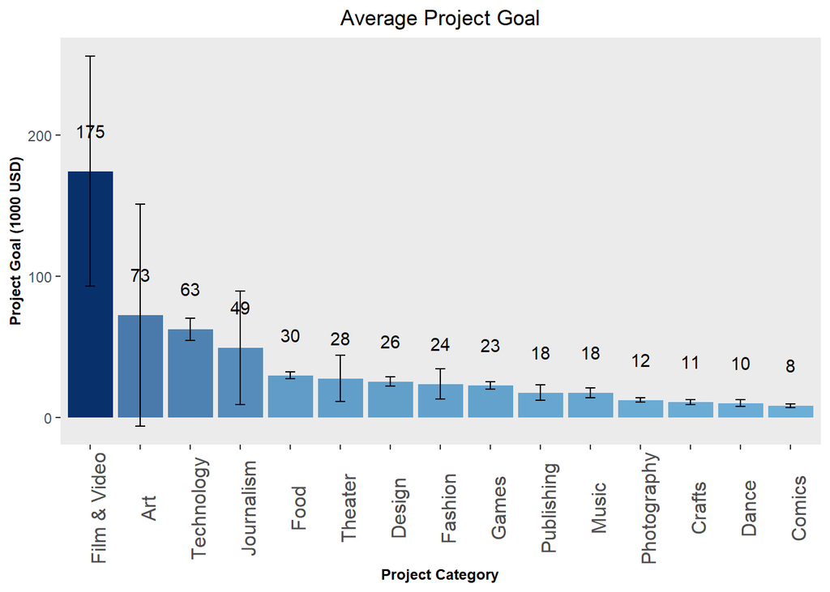

```r
# 90% CI, get z-value for upper tail, use .95 since is one sided
z <- qnorm(.95)

dat %>%
  group_by(category) %>%
  summarise(avg = mean(usd.goal),
            projects = n(),
            sd =sd(usd.goal),
            ci= z * sd/sqrt(projects)) %>%
  arrange(desc(avg)) %>%
  mutate(category = factor(category, levels = category)) %>%
  ggplot( aes(category, avg/1000, fill = avg)) + geom_bar(stat="identity") +
  ggtitle("Average Project Goal") + xlab("Project Category") + ylab("Project Goal (1000 USD)") +
  geom_text(aes(label =  round( avg/1000, 0)), vjust = -2.5) +
  theme(panel.grid = element_blank()) +
  theme(plot.title = element_text(hjust = 0.5), axis.title=element_text(size = 9, face = "bold"),
        axis.text.x = element_text(size = 12, angle = 90), legend.position = "null") +
  scale_fill_gradient(low ="#6baed6", high = "#08306b") +
  geom_errorbar(aes(ymin = (avg - ci)/1000, ymax = (avg + ci)/1000),
                width = 0.2 )
```

- Film & Video, Art, and Technology set the highest average project goals. On the opposite side, we find Crafts, Dance, and Comics.

##### Average amount pleged by category

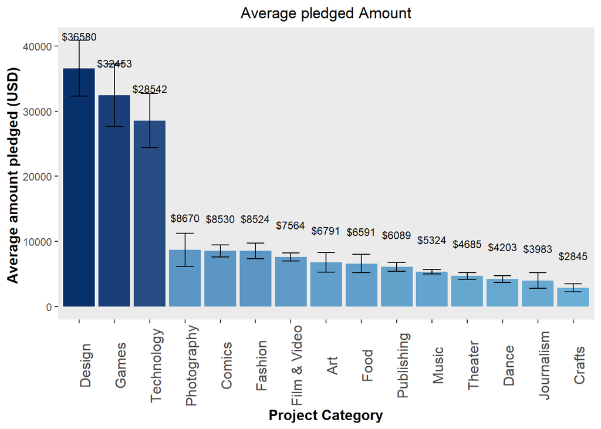

```r
dat %>%
  group_by(category) %>%
  summarise(avg=mean(usd.pledged), projects=n(),
            sd =sd(usd.pledged),
            ci= z * sd/sqrt(projects)) %>%
  arrange(desc(avg)) %>%
  mutate(category = factor(category, levels = category)) %>%
  ggplot( aes(category, avg, fill=avg)) + geom_bar(stat="identity") +
  ggtitle("Average pledged Amount") + xlab("Project Category") + ylab("Average amount pledged (USD) ") +
  geom_text(aes(label=paste0("$", round(avg,0))), vjust=-3.5, size = 3) +
  theme(panel.grid =element_blank()) +
  theme(plot.title=element_text(hjust=0.5), axis.title=element_text(size = 12, face="bold"),
        axis.text.x=element_text(size=12, angle=90), legend.position="null") +
  scale_fill_gradient(low="#6baed6", high="#08306b")+
  geom_errorbar(aes(ymin = avg - ci, ymax = avg + ci),
                width = 0.5)
```

- Design, Games, and Technology are the highest pledged amount grossing categories by far.
- Although number of backers of Games is double than Technology, Their average pledged amount only differ about 4000$.

##### Average amount donate by backers by category

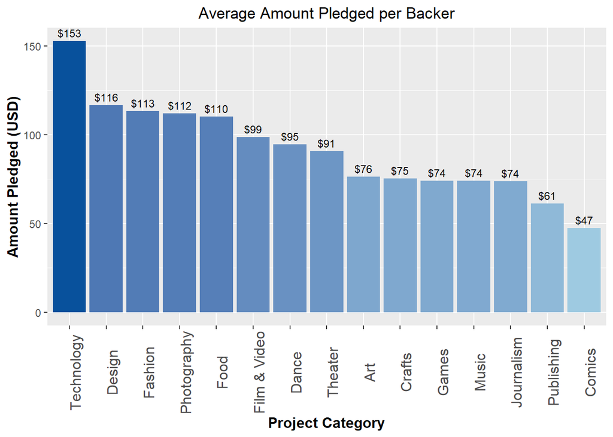

```r
dat %>%
  group_by(category) %>%
  summarise(pledged = sum(usd.pledged), sumbackers = sum(backers)) %>%
  mutate(avg = pledged/sumbackers) %>%
  arrange(desc(avg)) %>%
  mutate(category = factor(category, levels=category)) %>%
  ggplot( aes(category, avg , fill=avg)) + geom_bar(stat="identity") +
  ggtitle("Average Amount Pledged per Backer") + xlab("Project Category") + ylab("Amount Pledged (USD)") +
  geom_text(aes(label = paste0("$", round(avg,0))), vjust=-0.5, size = 3) +
  theme(plot.title=element_text(hjust=0.5), axis.title = element_text(size=12, face="bold"),
        axis.text.x=element_text(size=12, angle=90), legend.position="null") +
  scale_fill_gradient(low="#9ecae1", high="#08519c")
```

- While Games have most backers, the amount support from them is lower than Tachnology, Design and fashion
- Technology has the highest average amount pledged, whereas Comics has the lowest average amount pledged.
- An interesting note here is that the average amount pledged backers for Technology is approximately double to Games.

##### Amount pledged distribution by category

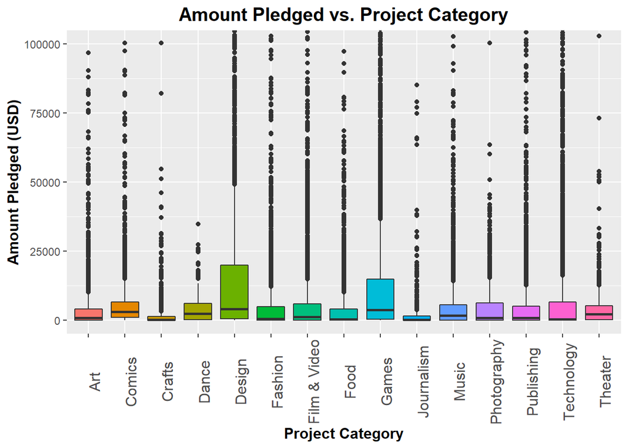

```r
ggplot(dat, aes(category, usd.pledged, fill= category)) + geom_boxplot() +
  ggtitle("Amount Pledged vs. Project Category") + xlab("Project Category") +
  ylab("Amount Pledged (USD)") +
  #facet_grid(. ~ state) +
  theme(plot.title=element_text(size=15, face="bold", hjust=0.5),
        axis.title=element_text(size=12, face="bold"),
        axis.text.x=element_text(size=12, angle=90), legend.position="null") +
  coord_cartesian(ylim=c(0,100000))
```

- Design and Game have a higher upper quartile compared to other categories.

#### 5.2.2.2 What types of projects were successful and unsuccessful?

##### Success and Failed by category

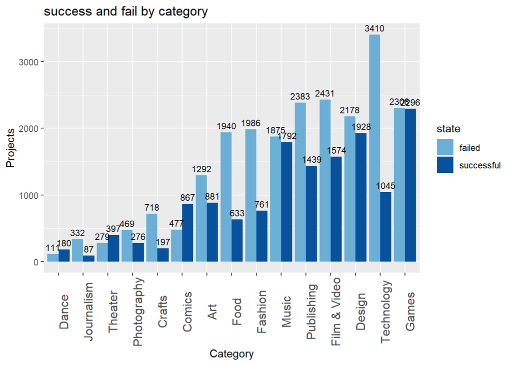

```r
#success fail by category
dat %>%
    group_by(category, state) %>%
    summarise(count = n(), total = sum(count)) %>%
    arrange(desc(state), count) %>%
    ggplot(aes(x= reorder(category, total), y = count, fill =state)) +
    geom_bar(stat="identity", position = "dodge") +
    geom_text(stat = "identity",
                  aes(label = count),
                   vjust =-.5,
                   position = position_dodge(0.9), size =3) +
        ggtitle("success and fail by category") +
        ylab("Projects")+
        xlab("Category") +
    #geom_label(aes(label = count), colour = "white", size = 3,  hjust =1, position = position_dodge(0.9))+
    stat_summary(geom = "errorbar", fun.data = "mean_cl_normal", width=0.2) +
    theme(axis.text.x=element_text(size=12, angle=90)) +
    scale_fill_manual(values = c("#6baed6","#08519c"))# +
```

```r
    #coord_flip()
```

- Comics, Theater, and Dance have more success than failure

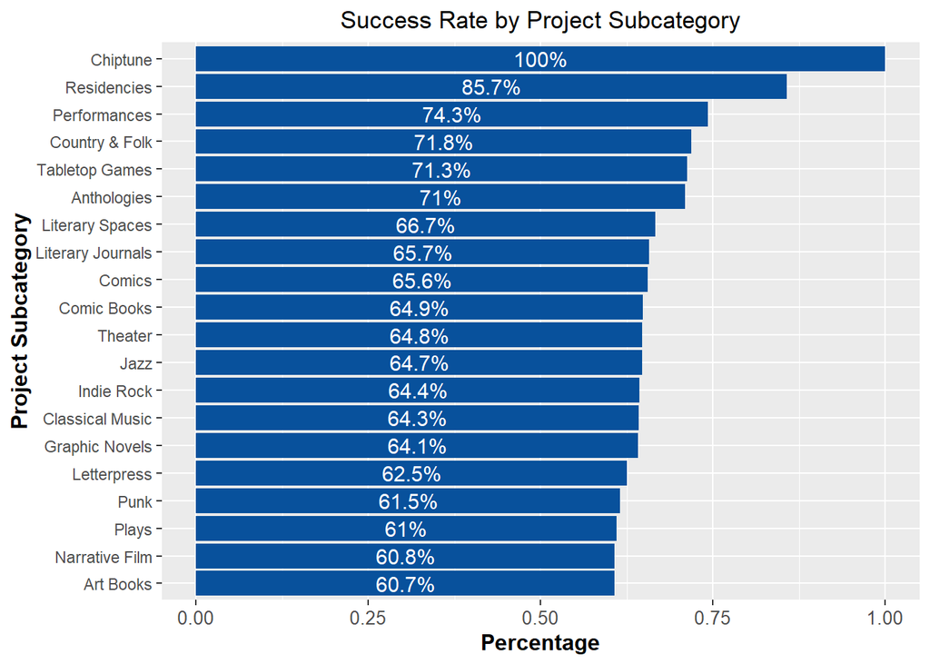

```r
dat %>%
  group_by(subcategory, state) %>%
  summarise(count=n()) %>%
  mutate(pct = count/sum(count))%>%
  arrange(desc(pct)) %>%
  filter(state != "failed") %>%
  head(20, pct) %>%
  ggplot(aes(x=reorder(subcategory, pct), y= pct)) + geom_bar(stat = "identity", fill ="#08519c") +
  ggtitle("Success Rate by Project Subcategory") +
  xlab("Project Subcategory") + ylab("Percentage")  +
  geom_text(aes(label=paste0(round(pct*100,1),"%")), position=position_stack(vjust=0.5),
            colour="white", size=4) +
  theme(plot.title=element_text(hjust=0.5), axis.title=element_text(size=12, face="bold"),
        axis.text.x=element_text(size=10), legend.position="bottom",
        legend.title=element_text(size=10, face="bold")) +
  coord_flip()
```

- Chiptune (Music) has 100% success.

#### 5.2.2.3 Length of Project

##### Number of project by length

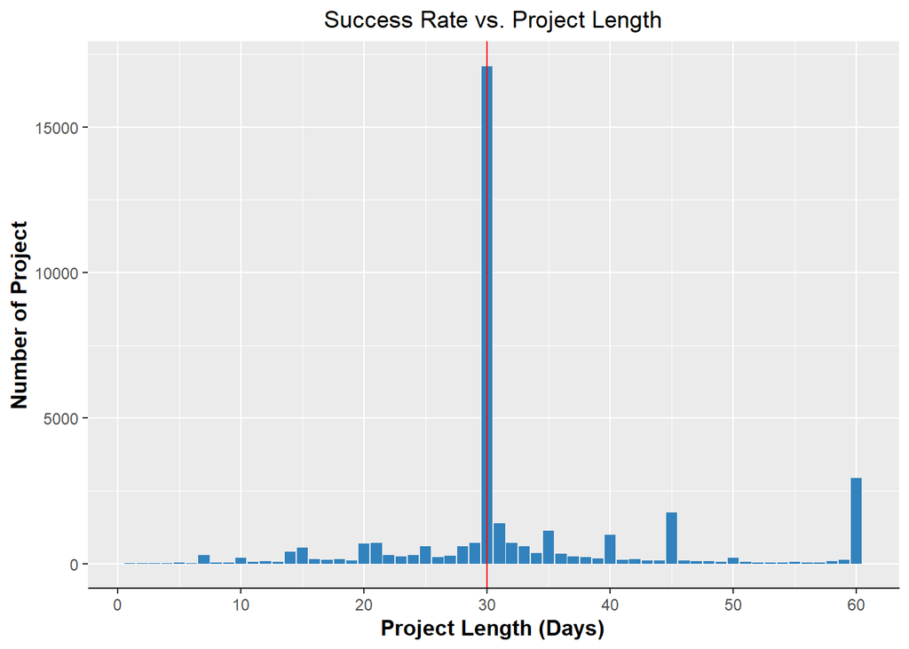

```r
dat %>%
  group_by(duration) %>%
  summarise(count=n()) %>%
  ggplot(aes(duration, count, fill =state)) +
  geom_bar(fill ="#3182bd",size=1.5, stat ="identity") + ggtitle("Success Rate vs. Project Length") +
  xlab("Project Length (Days)") + ylab("Number of Project") +
  scale_x_continuous(breaks=c(0,10,20,30,40,50,60)) + geom_vline(xintercept=30, colour="red") +
  theme(plot.title=element_text(hjust=0.5), axis.title = element_text(size=12, face="bold"),  axis.line.x = element_line())
```

- Most of project take around 30 days length

##### Project length in each category

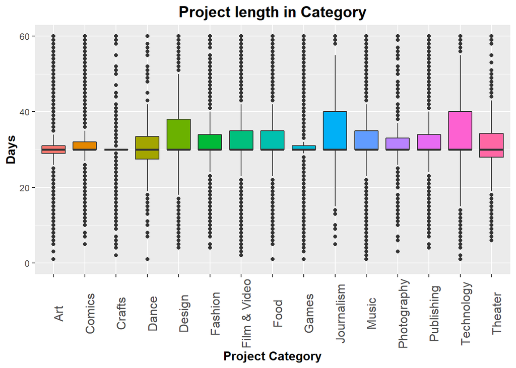

```r
ggplot(dat, aes(category, duration, fill= category)) + geom_boxplot() +
  ggtitle("Project length in Category") + xlab("Project Category") +
  ylab("Days") +
  #facet_grid(. ~ state) +
  theme(plot.title=element_text(size=15, face="bold", hjust=0.5),
        axis.title=element_text(size=12, face="bold"),
        axis.text.x=element_text(size=12, angle=90), legend.position="null") +
  coord_cartesian(ylim=c(0,60))
```

##### Project length density chart

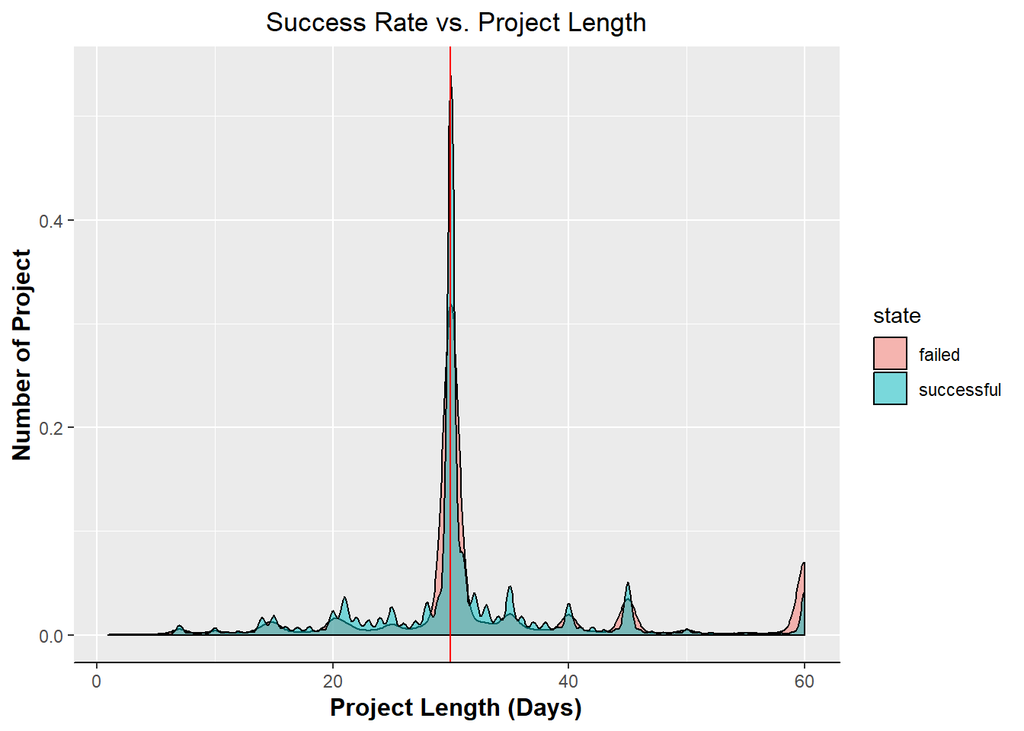

```r
dat %>%
  ggplot(aes(duration, fill = state)) +
  geom_density(alpha=.5) +
  ggtitle("Success Rate vs. Project Length") +
  xlab("Project Length (Days)") + ylab("Number of Project")  + geom_vline(xintercept=30, colour="red") +
  theme(plot.title=element_text(hjust=0.5), axis.title = element_text(size=12, face="bold"),  axis.line.x = element_line())
```

##### Success rate (successful project/total) by lenght

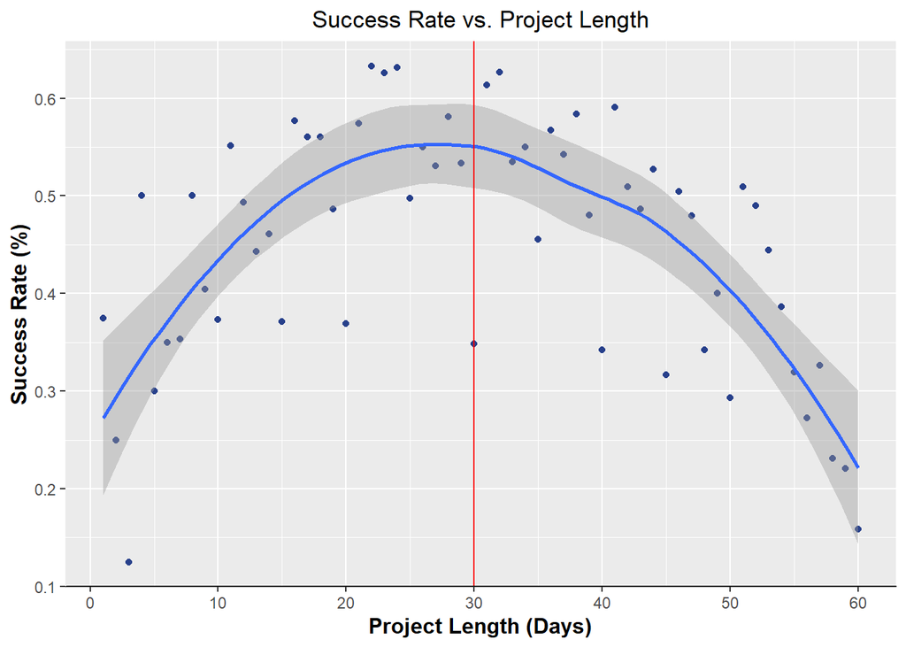

```r
dat %>%
  group_by(duration, state) %>%
  summarise(count=n()) %>%
  mutate(pct=count/sum(count)) %>%
  filter(state =="successful") %>%
  ggplot(aes(duration, pct)) +
  geom_point(colour="royalblue4", size=1.5) + ggtitle("Success Rate vs. Project Length") +
  geom_smooth() +
  xlab("Project Length (Days)") + ylab("Success Rate (%)") +
  scale_x_continuous(breaks=c(0,10,20,30,40,50,60)) + geom_vline(xintercept=30, colour="red") +
  theme(plot.title=element_text(hjust=0.5), axis.title = element_text(size=12, face="bold"),  axis.line.x = element_line())
```

- Overall, Projects longer 30days have lower success rate than projects lasting less than 30days.
- Highest success rate falls between 20 and 32 days.
- 30 days length project has medium success rate (35%). It may because most of project set up lenght = 30 days.

##### Pledged amount vs length of project

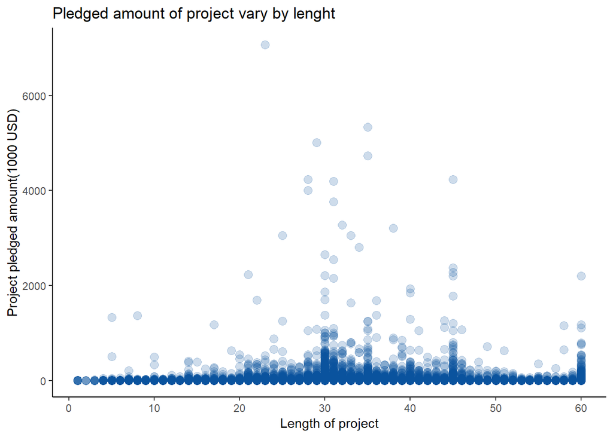

```r
dat %>%
  ggplot(aes(x=duration, y= usd.pledged/1000)) +
  geom_point(alpha = 0.2, colour = "#08519c", size =3) +
  #facet_grid(.~state) +
  ggtitle("Pledged amount of project vary by lenght") +
  xlab("Length of project") + ylab("Project pledged amount(1000 USD)") +
  theme_bw() +
  theme(panel.grid =element_blank()) +
  #theme(axis.ticks = element_blank()) +
  scale_x_continuous(breaks=c(0,10,20,30,40,50,60)) +
  theme(axis.line = element_line(colour = "black")) +
  theme(panel.border = element_blank())
```

- Project has leghts fall between 20 - 45 funded more money than those others.

##### Number of backers vs length of project

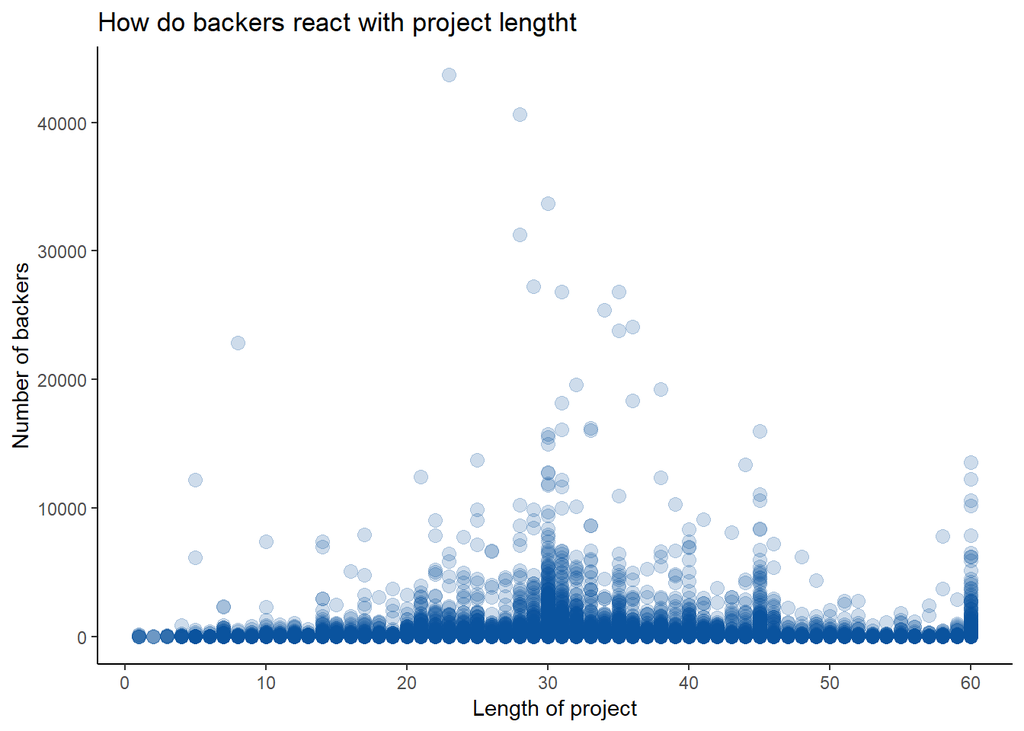

```r
dat %>%
  ggplot(aes(x=duration, y=backers)) +
  geom_point(alpha = 0.2, colour = "#08519c", size =3) +
  #facet_grid(.~state) +
  ggtitle("How do backers react with project lengtht") +
  xlab("Length of project") + ylab("Number of backers") +
  theme_bw() +
  theme(panel.grid =element_blank()) +
  #theme(axis.ticks = element_blank()) +
  scale_x_continuous(breaks=c(0,10,20,30,40,50,60)) +
  theme(axis.line = element_line(colour = "black")) +
  theme(panel.border = element_blank())
```

- This graph has similar pattern as previous graph. Backers seem to prefer project have medium lenght than longer projects.

##### Number of backers vs length of project vary by category

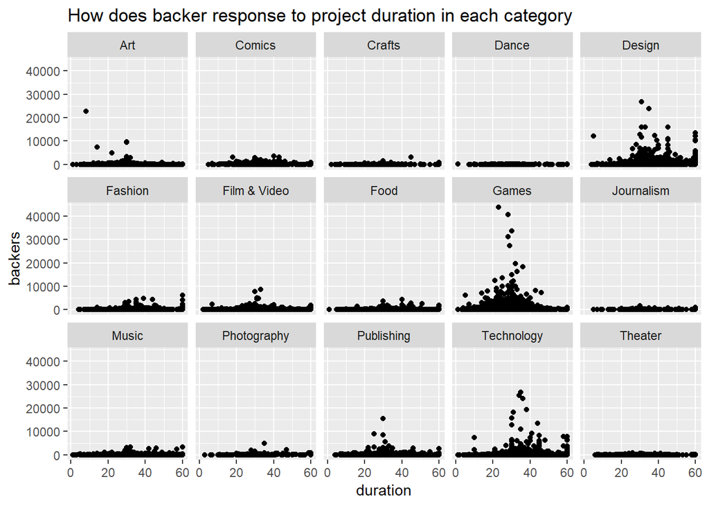

```r
dat %>%
    ggplot(aes(x = duration, y=backers)) +
    geom_point()+
    #geom_bar(stat ="count")+
    facet_wrap(. ~ category, ncol =5) +
    ggtitle("How does backer response to project duration in each category")
```

- Although it is not clearly to recognize the pattern for some category, but backers usually interested in project have length fall in [20,40] days.

#### 5.2.2.4 country

It would be nice to know what countries Kickstarter projects are originating from. I think it would look much nicer if we used a geographical heat map instead.

```r
# create freq dataframe include country
countries.freq <- dat %>%
                  filter(country!='N,0"') %>%
                  group_by(country) %>%
                  summarise(count=n())

#join country in datafram with map
countries.match <- joinCountryData2Map(countries.freq, joinCode="ISO2", nameJoinColumn="country")
```

```
## 22 codes from your data successfully matched countries in the map
## 0 codes from your data failed to match with a country code in the map
## 220 codes from the map weren't represented in your data
```

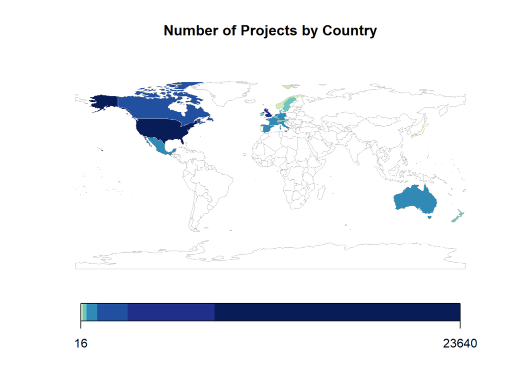

```r
#visual map
mapCountryData(countries.match, nameColumnToPlot="count",
               mapTitle="Number of Projects by Country", catMethod="logFixedWidth",
               colourPalette = c("#ffffd9","#c7e9b4","#41b6c4","#225ea8","#253494","#081d58"))
```

- Projects seem to primarily originate from North America, Europe, and Oceania

##### Success Rate in Countries

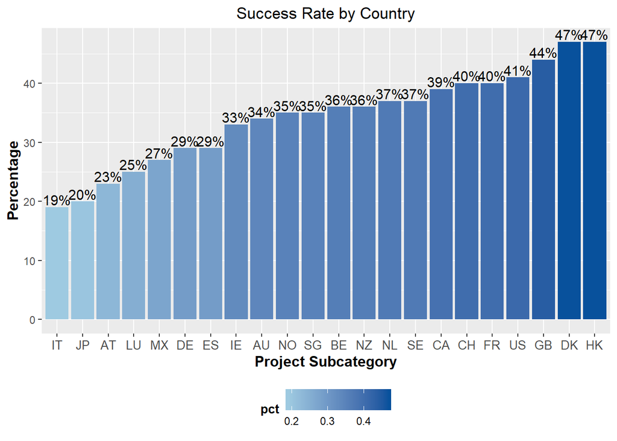

```r
dat %>% select(country, state) %>%
        group_by(country, state) %>%
        summarise(count = n()) %>%
        mutate(pct = round(count/sum(count),2)) %>%
        filter(state=="successful") %>%
        arrange(desc(pct)) %>%
        ggplot(aes(reorder(country, pct), round(pct *100,1),fill =pct)) +
        geom_bar(stat = "identity") +
        ggtitle("Success Rate by Country") +
        xlab("Project Subcategory") + ylab("Percentage")  +
        geom_text(aes(label=paste0(round(pct*100,0),"%")), vjust =-0.2,
                  colour="Black", size=4) +
        theme(plot.title=element_text(hjust=0.5), axis.title=element_text(size=12, face="bold"),
              axis.text.x=element_text(size=10), legend.position="bottom",
              legend.title=element_text(size=10, face="bold")) +
        #coord_flip() +
        scale_fill_gradient(low="#9ecae1", high="#08519c")
```

# 6. Detail EDA

To assess a success of a project, I created a field named “Ratio” = uds.pledged/usd.goal. If ratio >=1 it means project is successful and <1 otherwise

### Which category has higher crowdfunding rate?

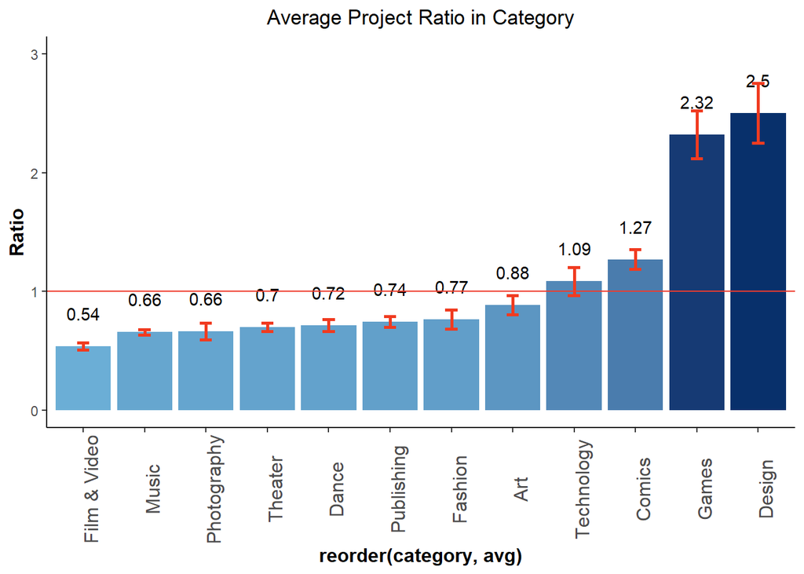

```r
#Average Ratio vs Category
dat %>% group_by(category) %>%
        summarise(avg = mean(ratio), sd= sd(ratio),
                  n = n(),
                  ci= z * sd/sqrt(n)) %>%
        arrange(desc(avg)) %>% head(12) %>%
        ggplot(aes(x = reorder(category,avg), y =avg, fill = avg)) +
        geom_bar(stat="identity") +
        ggtitle("Average Project Ratio in Category") +
        ylab("Ratio") +
        ylim(0,3) +
        geom_text(aes(label =  round( avg, 2)), vjust =-2 ) +
        theme_bw() +
        theme(panel.grid = element_blank()) +
        theme(panel.border = element_blank())  +
        theme(axis.line = element_line(colour = "black")) +
        theme(plot.title = element_text(hjust = 0.5), axis.title=element_text(size = 12, face = "bold"),
              axis.text.x = element_text(size = 12, angle = 90), legend.position = "null") +
        scale_fill_gradient(low ="#6baed6", high = "#08306b") +
        geom_errorbar(aes(ymin = (avg - ci), ymax = (avg + ci)),
                      width = 0.2, colour ="#f03b20", size =1 )+
        geom_hline(yintercept = 1, colour ="#ef3b2c")
```

- Categories have average ratio higher than 1 are more like to success than those below 1.
  - Design, Games, Comics have high ratio.
  - Technology just slightly higher than 1, but the error bar quite big.

### Whether lenght of project affect to funding ratio?

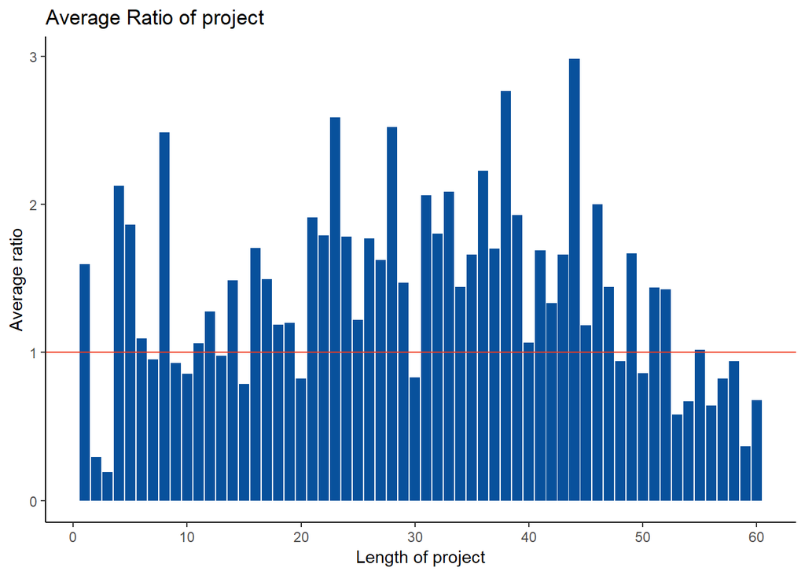

```r
dat %>% group_by(duration) %>%
        summarise(avg = mean(ratio), sd = sd(ratio),
                  n = n(),
                  ci= z * sd/sqrt(n)) %>%
  ggplot(aes(x = duration, y = avg)) +
  geom_bar(stat ="identity", fill = "#08519c") +
  #facet_grid(.~state) +
  ggtitle("Average Ratio of project") +
  xlab("Length of project") +
  ylab("Average ratio") +
  geom_hline(yintercept = 1, colour = "#f03b20") +
  theme_bw() +
  theme(panel.grid = element_blank()) +
  #theme(axis.ticks = element_blank()) +
  scale_x_continuous(breaks=c(0,10,20,30,40,50,60)) +
  theme(axis.line = element_line(colour = "black")) +
  theme(panel.border = element_blank())
```

### How well dose project crowdfund ?

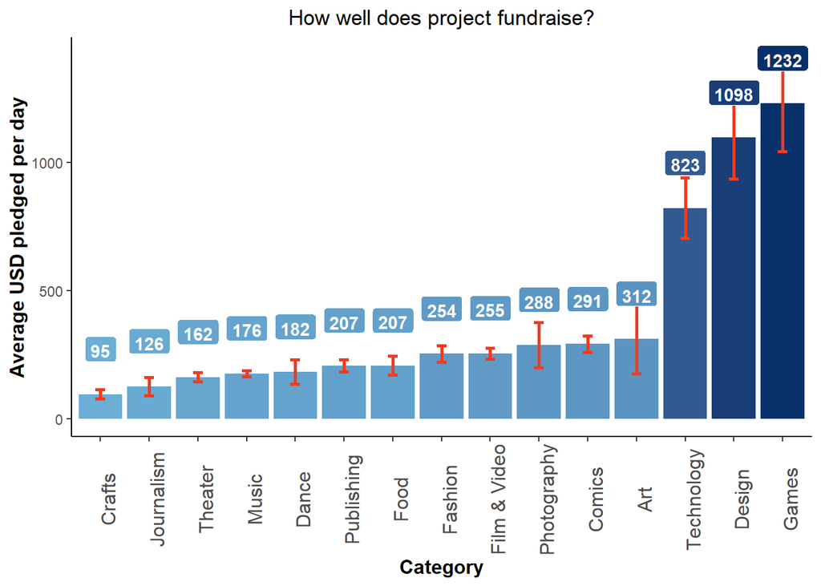

```r
dat %>% select(category, usd.pledged, duration) %>%
        mutate(speed = round(usd.pledged/duration,0)) %>%
        group_by(category) %>%
        summarise(avg = mean(speed),
               sd= sd(speed),
               n = n(),
               ci= z * sd/sqrt(n)) %>%
        ggplot(aes(x = reorder(category,avg), y= avg, fill =avg)) +
        geom_bar(stat ="identity") +
        geom_errorbar(aes(ymin = (avg - ci), ymax = (avg + ci)),
                      width = 0.2, colour ="#f03b20", size =1) +
        ggtitle("How well does project fundraise?") +
        xlab("Category")+
        ylab("Average USD pledged per day") +
        #geom_text(aes(label =  round( avg,0)), vjust = -3) +
        geom_label(aes(label =  round( avg,0)), vjust = -1.3,colour = "white", fontface = "bold") +
        theme_bw() +
        theme(panel.grid = element_blank()) +
        theme(panel.border = element_blank())  +
        theme(axis.line = element_line(colour = "black")) +
        theme(plot.title = element_text(hjust = 0.5), axis.title=element_text(size = 12, face = "bold"),
              axis.text.x = element_text(size = 12, angle = 90), legend.position = "null") +
        scale_fill_gradient(low ="#6baed6", high = "#08306b")
```

- Games, Design and Technology are fast fundrasing project.
- Project owner should consider crowdfunding speed to set their minimal goal and project length.

### Average goal of successfull and unsuccessfull project

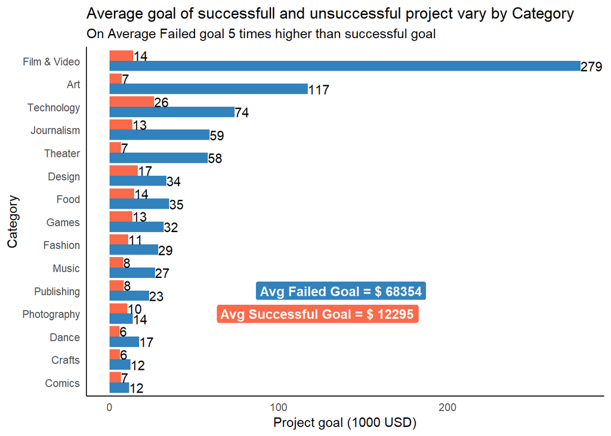

```r
  avg_goal <- mean(dat$usd.goal[dat$state =="successful"])
  avg_fgoal <- mean(dat$usd.goal[dat$state =="failed"])
  dat %>%
    group_by(category, state) %>%
    summarise(totalgoal = sum(usd.goal), count = n()) %>%
    mutate(avggoal = totalgoal/count) %>%
    ggplot(aes(x=reorder(category, avggoal), y = avggoal/1000, fill = state)) +
    geom_bar(stat ="identity", position ="dodge") +
    coord_flip() +
    ggtitle("Average goal of successfull and unsuccessful project vary by Category",
            sub="On Average Failed goal 5 times higher than successful goal") +
    xlab("Category") + ylab("Project goal (1000 USD)") +
    #ylim(0,300)+
    #scale_y_continuous(breaks=c(0,10,25,50,100,150,200,300)) +
    scale_fill_manual(values = c("#3182bd","#fb6a4a")) +
    geom_text(stat = "identity",
    aes(label = round(avggoal/1000,0)),
    hjust = 0,
    position = position_dodge(0.9)) +
    #geom_hline(yintercept = avg_goal)
    geom_label(x=4, y=avg_goal/100, aes(label= paste("Avg Successful Goal = $", round(avg_goal,0))),colour = "white", fontface = "bold", fill ="#fb6a4a" ) +
    geom_label(x=5, y=avg_fgoal/500, aes(label= paste("Avg Failed Goal = $", round(avg_fgoal,0))),colour = "white", fontface = "bold", fill ="#3182bd" ) +
    theme_bw() +
    theme(panel.grid =element_blank()) +
    #theme(axis.text.x = element_blank()) +
    theme(legend.position = "none") +
    theme(axis.ticks = element_blank()) +
    theme(axis.line = element_line(colour = "black")) +
    theme(panel.border = element_blank())
```

- Successfull project tend to set up its goal lower than failed project. Higher goal related to higher rate of failure.
  - Backers might feel more risky with project set the goal too high.
  - Project owener should set a realistic minimum goal to create credibility and attract backers.

# 7. Statistical EDA

## 7.1 Logit model

```r
# estimate logit model, dependent variable is probability of successfull
logitdat <- dat%>%
            mutate(outcome = as.factor(ifelse(state =="successful",1,0)))
logitmodel <- glm(data =logitdat, outcome ~ usd.goal + duration + category +backers, family = "binomial" )
summary(logitmodel)
```

```
##
## Call:
## glm(formula = outcome ~ usd.goal + duration + category + backers,
##     family = "binomial", data = logitdat)
##
## Deviance Residuals:
##     Min       1Q   Median       3Q      Max
## -8.4904  -0.4811  -0.0746   0.0959   8.4904
##
## Coefficients:
##                        Estimate Std. Error z value Pr(>|z|)
## (Intercept)          -6.905e-01  8.058e-02  -8.570  < 2e-16 ***
## usd.goal             -1.462e-04  2.982e-06 -49.036  < 2e-16 ***
## duration             -1.345e-02  1.695e-03  -7.935 2.10e-15 ***
## categoryComics       -6.484e-01  1.127e-01  -5.754 8.72e-09 ***
## categoryCrafts       -7.032e-01  1.271e-01  -5.531 3.19e-08 ***
## categoryDance         1.028e+00  1.658e-01   6.201 5.60e-10 ***
## categoryDesign       -2.129e-01  8.413e-02  -2.530 0.011399 *
## categoryFashion      -4.420e-01  8.874e-02  -4.981 6.32e-07 ***
## categoryFilm & Video  2.531e-01  7.753e-02   3.265 0.001096 **
## categoryFood         -3.516e-01  9.638e-02  -3.648 0.000264 ***
## categoryGames        -1.615e+00  9.295e-02 -17.375  < 2e-16 ***
## categoryJournalism   -8.108e-01  1.997e-01  -4.059 4.93e-05 ***
## categoryMusic         2.053e-01  7.774e-02   2.641 0.008262 **
## categoryPhotography  -3.059e-01  1.286e-01  -2.379 0.017348 *
## categoryPublishing   -5.157e-01  8.159e-02  -6.321 2.60e-10 ***
## categoryTechnology   -5.105e-01  9.262e-02  -5.512 3.56e-08 ***
## categoryTheater       8.737e-01  1.207e-01   7.237 4.60e-13 ***
## backers               4.752e-02  6.065e-04  78.345  < 2e-16 ***
## ---
## Signif. codes:  0 '***' 0.001 '**' 0.01 '*' 0.05 '.' 0.1 ' ' 1
##
## (Dispersion parameter for binomial family taken to be 1)
##
##     Null deviance: 48965  on 36541  degrees of freedom
## Residual deviance: 20124  on 36524  degrees of freedom
## AIC: 20160
##
## Number of Fisher Scoring iterations: 14
```

- Most of estimated coefficients are statistical significant. Only Design and Photography are significant at 5% level.
- Usd goal and duration coefficients are negative and statistical significant.
- Higher goal and longer duration reduce the success probability of project.
- Number of backers has positive effect to probabilty of successful.

## Coefficient table

```r
# CI and odd ratio
coelogit <- summary(logitmodel)$coefficients
upper.ci<-as.data.frame(exp(summary(logitmodel)$coef[,1] + 1.96*summary(logitmodel)$coef[,2]) )
lower.ci<-as.data.frame(exp(summary(logitmodel)$coef[,1] - 1.96*summary(logitmodel)$coef[,2]) )

#put all into one dataframe
coe_logit <- as.data.frame(cbind(coelogit[-1, ], exp(coef(logitmodel))[-1],  lower.ci[-1,],upper.ci[-1,]))

#naming col
names(coe_logit) <- c("estimate", "se", "t", "pval","odd_ratio", "low_CI", "high_CI")
#create table for viz
htmlTable(round(coe_logit[order(coe_logit$pval, decreasing = FALSE), ], 3))
```

|  | estimate | se | t | pval | odd_ratio | low_CI | high_CI |
| --- | --- | --- | --- | --- | --- | --- | --- |
| usd.goal | 0 | 0 | -49.036 | 0 | 1 | 1 | 1 |
| backers | 0.048 | 0.001 | 78.345 | 0 | 1.049 | 1.047 | 1.05 |
| categoryGames | -1.615 | 0.093 | -17.375 | 0 | 0.199 | 0.166 | 0.239 |
| duration | -0.013 | 0.002 | -7.935 | 0 | 0.987 | 0.983 | 0.99 |
| categoryTheater | 0.874 | 0.121 | 7.237 | 0 | 2.396 | 1.891 | 3.035 |
| categoryPublishing | -0.516 | 0.082 | -6.321 | 0 | 0.597 | 0.509 | 0.701 |
| categoryDance | 1.028 | 0.166 | 6.201 | 0 | 2.795 | 2.02 | 3.869 |
| categoryComics | -0.648 | 0.113 | -5.754 | 0 | 0.523 | 0.419 | 0.652 |
| categoryCrafts | -0.703 | 0.127 | -5.531 | 0 | 0.495 | 0.386 | 0.635 |
| categoryTechnology | -0.51 | 0.093 | -5.512 | 0 | 0.6 | 0.501 | 0.72 |
| categoryFashion | -0.442 | 0.089 | -4.981 | 0 | 0.643 | 0.54 | 0.765 |
| categoryJournalism | -0.811 | 0.2 | -4.059 | 0 | 0.445 | 0.301 | 0.658 |
| categoryFood | -0.352 | 0.096 | -3.648 | 0 | 0.704 | 0.582 | 0.85 |
| categoryFilm & Video | 0.253 | 0.078 | 3.265 | 0.001 | 1.288 | 1.106 | 1.499 |
| categoryMusic | 0.205 | 0.078 | 2.641 | 0.008 | 1.228 | 1.054 | 1.43 |
| categoryDesign | -0.213 | 0.084 | -2.53 | 0.011 | 0.808 | 0.685 | 0.953 |
| categoryPhotography | -0.306 | 0.129 | -2.379 | 0.017 | 0.736 | 0.572 | 0.948 |

- Consider the estimated odds ratio:
  - Each additional backers increase the estimated odds of success 4.9%
  - 1 days increase in length reduce the estimated odds of success 1.3%
  - Theater, Dance, Film & Video and Music have higher estimated odds of success than Art.
- All estimate odds ratio are statistically significant.

## Plot Odd ratio and confident interval

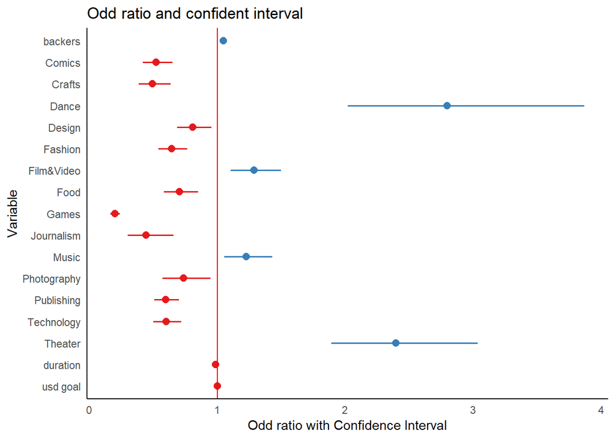

```r
#odds ratio plot
plot_model(logitmodel) +
  theme_bw() +
  ylab("Odd ratio with Confidence Interval") +
  xlab("Variable") +
  ggtitle("Odd ratio and confident interval")+
  ylim(min(coe_logit$low_CI), max(coe_logit$high_CI)) +
  geom_hline(yintercept = 1, color = "red") +
  theme_bw() +
  theme(panel.grid =element_blank()) +
  theme(axis.ticks = element_blank()) +
  theme(axis.line = element_line(colour = "black")) +
  theme(panel.border = element_blank())
```

- As expected, Dance, Theater have high odd ratio compare to Art. But CI is bigger than others
- Film & Video, and Music also have higher probability to success than art. Other remain category have lower odd ratio.
- Another Surprises is Game has lowest odd ratio.
- Backers has positive effectm while duration and goal have negative effects.

# 8. Summary of results

**Category**: + The dataset has 15 different main category. Theater, Dance and Comic project have highest success rate which higher than 60%. + Game, Technology and Design are the most interesting project which attract many backers, they also account for major proportion of project on Kickstarters.

**Goal and pledged amount**: + Design, Game and Technology pledged highest amount corresponding to number of backers. On the other hand, Art related project like Film & Video, Art tend to set a minimal goal too high even they only can pledged money as a fifth compare to game. On average, unsuccessful rate set its minimum goal 5 times higher than successful goal.

**Duration**: most of projects have length fall in 20~40 days, this is also the popular duration for successful projects. Successful rate of project shorter than 30days slightly higher than project longer 30days. 30days and 60days length have 35% and 15% success rate respectively.

**Ratio**: Game and Designe have highest pledgeed/goal ratio with average ratio are 2.32 and 2.5 respectivelive.

**Backer**: Many backers interested in Game, Design and technology projects. Backers less support to projects which are too long or set too high goal.

**Logit model**: Each backer increase can increase 4.8% probability of success of project. While 1 day increase in duration reduce 1.3% of probability. Compare to Art based project, Film & Video, music, Theater and Dance have higher odd of success. All of variable has statitical coefficient to probability of success.

# 9. Conclusion

## what should project owner know about crowdfunding campaign on Kickstarter?

There are many factors affect to the successfull rate of a crowdfunding campaign on Kickstarter. From this analysis, we can see that Dance, Theater and comic based project have higher success rate than other which about 60%, the reason for this result could be relate to low risk rate of a project. However these type of project do not attract most backers and fundraise high amount of money, also there are fewer projects in these type compare to Games, Technology and Design. Project category seems to be not a important factor affect to success of a campain, but it reflect how much attractive of your project and this is more important. Games, Design, Technology and comics are four most attractive project category which attract most backers to support. With a plenty of backers these type of project can pledged high amount of money for their project. Nevertheless, these projet also face high competition rate.

Besides category of project I also found 3 factors: Backers, Duration and minimum goal.

- **Number of backers** has a strong impact to the success of a crowdfunding campaign. Of course the more backers you have the more money you fund. Hence, project owners should consider how to attract more backer to support their project. There are many things to do to attract backers like well design description, backers reward, marketing, ect… which we can not cover in this analysis.
- **Duration**: Longer campaign faces a higher failed rate. Most successful campaigns have length from 20 to 40 days. Longer project could make Backers worry about its posibility to success crowdfunding although long duration give you more time to fundraise.
- **minimum goal**: Too high goal seems feasible to complete within project duration. Comparing between successful and unsuccessful project, on vaerage unsuccessful project set a minimum goal 5 times higher than successful projects. It create a suspicion in backers. Kickstater is a online crowdfunding platform, backers have more factor to consider rather than project itself such as scam, fraud, ROI. Instead set up a high goal for your entire project, Creator should consider divide the project into multi phrases of crowdfunding

**Conclusion** Control other factors which are not covered in this analysis like potential of project, creativity, marketing… To run a crowdfunding campaign successfully on Kickstarter, project owners and companies should consider attracting backers by seting up their projects’ goal and lenght.

**Limitaion and future analysis** There are some limitaion in this data analysis regarding time, dataset. In future, I would like to conduct futher analysis which consider text analysis and predicting.

# 10. Graph for Dashboar, Presentation and Story telling

### When is a good time to launch a campaign

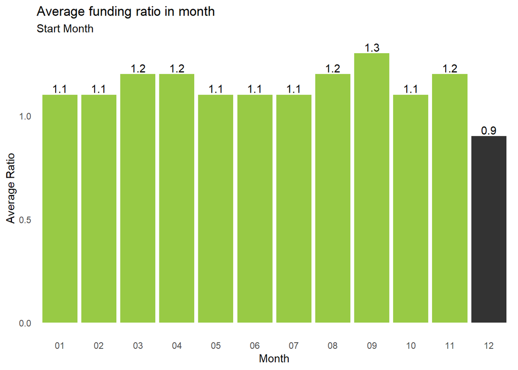

```r
dat %>%
    group_by(month) %>%
    summarise(avg = round(mean(ratio),1)) %>%
    ggplot(aes(x = factor(month), y=avg ,fill = factor(ifelse(avg >=1,"no", "yes" )))) +
    geom_bar(stat= "identity") +
    scale_fill_manual(values = c("no"="#98ca45","yes" = "#333333")) +
    ggtitle(label ="Average funding ratio in month",sub ="Start Month")+
    xlab("Month") + ylab("Average Ratio") +
    #geom_hline(yintercept = 1, colour ="#fb6a4a", size =2)+
    theme_bw() +
    theme(panel.grid = element_blank()) +
    theme(axis.ticks = element_blank()) +
    theme(axis.line =  element_blank()) +
    theme(panel.border = element_blank()) +
    theme(legend.position = "none") +
    geom_text(aes(label = avg), vjust = -.25)
```

```r
ggsave("finding3-1.png")
```

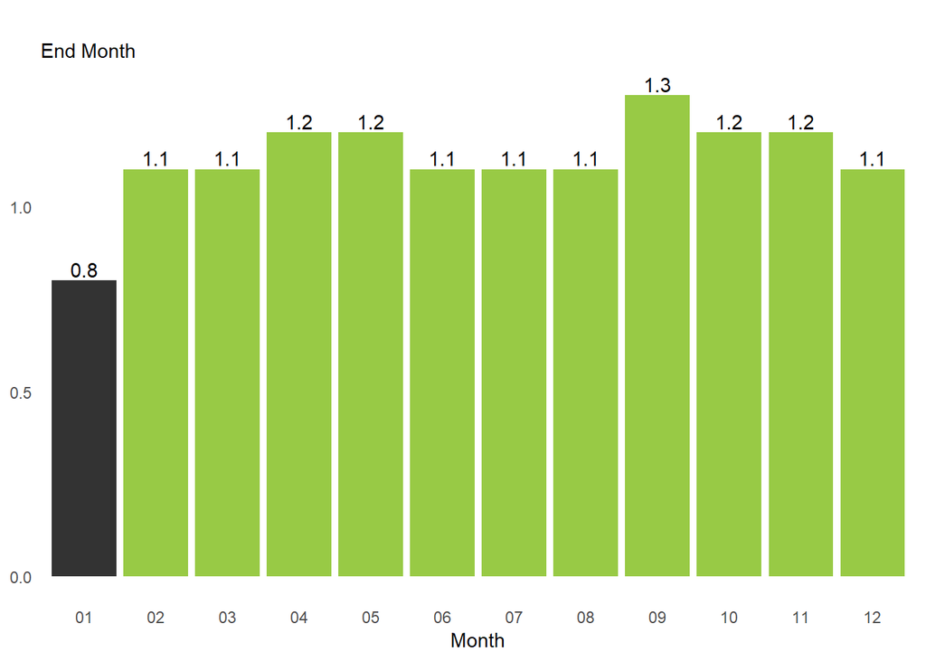

```r
    dat %>%
    mutate(Monthend= format(deadline, "%m")) %>%
    group_by(Monthend) %>%
    summarise(avg = round(mean(ratio),1)) %>%
    ggplot(aes(x = factor(Monthend), y = avg, fill = factor(ifelse(avg >=1,"no", "yes" )))) +
    geom_bar(stat= "identity") +
    scale_fill_manual(values =c("no" = "#98ca45","yes" = "#333333")) +
    ggtitle(label ="",sub ="End Month") +
    xlab("Month") +
    ylab("Average Ratio") +
    #geom_hline(yintercept = 1, colour ="#fb6a4a", size =2)+
    theme_bw() +
    theme(panel.grid =element_blank()) +
    theme(axis.ticks = element_blank(), axis.title.y= element_blank()) +
    theme(legend.position = "none") +
    theme(axis.line = element_blank()) +
    theme(panel.border = element_blank()) +
    geom_text(aes(label = avg), vjust = -.25)
```

```r
ggsave("finding3-2.png")
```

### Most interesting category

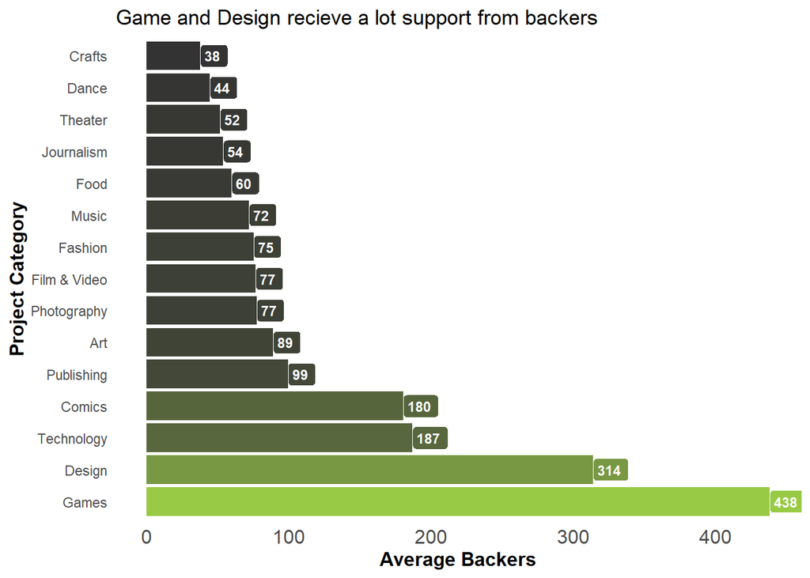

```r
dat %>%
  group_by(category) %>%
  summarise(sumbackers = mean(backers)) %>%
  arrange(desc(sumbackers)) %>%
  mutate(category = factor(category, levels=category)) %>%
  ggplot( aes(category, sumbackers, fill=sumbackers)) + geom_bar(stat="identity") +
  ggtitle("Game and Design recieve a lot support from backers") + xlab("Project Category") + ylab("Average Backers") +
  geom_label(aes(label= round(sumbackers,0)),  hjust = 0, size = 3,fontface = "bold", colour ="white") +
  theme_bw() +
  theme(plot.title=element_text(), axis.title=element_text(size=12, face="bold"),
        axis.text.x=element_text(size=12), legend.position="null") +
  theme(panel.grid =element_blank()) +
  theme(axis.ticks = element_blank()) +
  theme(panel.border = element_blank()) +
  scale_fill_gradient(low="#333333", high= "#98ca45") + coord_flip()
```

```r
ggsave("storyfovcateg.png")
```

### success rate vs Project length

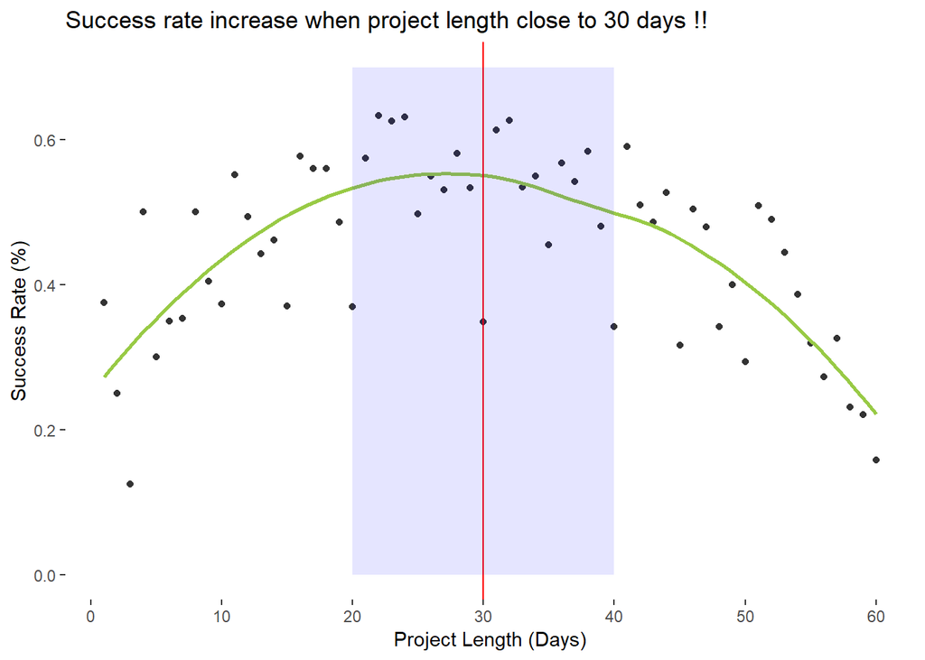

```r
dat %>%
  group_by(duration, state) %>%
  summarise(count=n()) %>%
  mutate(pct=count/sum(count)) %>%
  filter(state =="successful") %>%
  ggplot(aes(duration, pct)) +
  geom_point(colour="#333333", size=1.5) + ggtitle("Success rate increase when project length close to 30 days !!") +
  geom_smooth(se=FALSE, colour ="#98ca45" ) +
  xlab("Project Length (Days)") +
  ylab("Success Rate (%)") +
  scale_x_continuous(breaks=c(0,10,20,30,40,50,60)) +
  geom_vline(xintercept=30, colour="red") +
  annotate("rect", xmin=20, xmax=40, ymin=0, ymax=0.7, alpha=.1,
          fill="blue")+
  theme(plot.title=element_text(hjust=0.5),
        axis.title = element_text(size=12, face="bold"),
        axis.line.x = element_line(),
        legend.position="null")+
  theme_bw() +
  #theme(axis.line = element_line(colour = "black")) +
  theme(panel.grid =element_blank()) +
  theme(panel.border = element_blank())
```

```r
 #save image for presentation
    ggsave("finding2.png")
```